# 全球與台灣 ESG 績效評比、永續排名與揭露分析體系深度研究報告

本報告由 Gemini Deep Research（gemini.google.com，2026 年 11 月 24 日）產出，原始 Google 文件為「全球與台灣 ESG 評比方法總覽」。轉檔時只修正用字（台灣繁體中文與台灣用語、刪除套語句型與破折號），事實內容未更動。內文方括號數字對應文末「參考來源」編號；所有網址已於 2026 年 11 月 24 日逐一連線驗證，結果見附錄與「URL驗證紀錄_Gemini_20261124.csv」。

全球與台灣的企業永續評估體系，已從早期由社會責任投資（SRI）倡議驅動的利基研究，發展為高度分眾的資料基礎設施與資本市場定價工具。依核心目的與資料機制劃分，現行機構與研究團隊可歸納為四大陣營：以投資人財務風險為核心的**國際商業評等與指數資料庫**（如 MSCI、Sustainalytics、S&P Global CSA、LSEG、Bloomberg、FTSE Russell、ISS ESG）、以供應鏈審查與外部影響力問責為主軸的**專題問卷與非營利基準**（如 CDP、EcoVadis、WBA）、以本土法規引導、在地資料庫或品牌競賽為主的**台灣評鑑、資料庫與獎項**（如證交所 ESG 評鑑、TEJ TESG、TIP 台灣永續評鑑、天下、遠見、TCSA），以及專注於檢驗揭露品質、文本語言與評等信度的**學術研究方法**（如 GRI 揭露指數、Clarkson 硬性／軟性評分、NLP／LLM 自動化剖析與評等分歧研究） [1]。

在比較各家評比或設計永續揭露研究前，有三個基本界線必須先釐清。第一，**準則制定者並非評等機構**：GRI、SASB 與 ISSB（IFRS S1／S2）負責訂定企業「應該揭露什麼資訊」，屬於上游報導規範，本身不對個別企業打分數 [6]。第二，**不同機構測量的其實是不同概念**：MSCI 與 Sustainalytics 衡量的是「ESG 議題對企業財務價值的單向風險（財務重大性）」，WBA 與 GRI 聚焦於「企業營運對人與環境的外部衝擊（影響重大性）」，而 Bloomberg ESG Disclosure Score 與多數 GRI 檢核指數衡量的則是「揭露完整度」而非實質永續績效 [1]。第三，**商業評等間高度分歧，且市場正處於監管重組期**：MIT Sloan 團隊實證指出，六大國際 ESG 評等機構的平均兩兩相關係數僅 0.54，遠低於信用評等的 0.94–0.96；伴隨歐盟《ESG 評等規章》（Regulation (EU) 2024/3005）於 2026 年 7 月起適用，市場出現大型整併（如 Moody's 於 2024 年關閉自有 ESG 評等業務並轉與 MSCI 合作），台灣亦於 2026 年度正式將實施逾十年的公司治理評鑑轉型為「ESG 評鑑」 [5]。

以下依國際體系、台灣本土體系與學術方法論三部分，逐一說明各機構或方法的起始年份、資料來源、指標與計分方式、GRI 關聯與跨年資料能力，並於文末彙整完整總表，深入比對這些體系與「以公開永續報告書逐題對照 GRI 準則計分、對上百家台灣上市公司做跨年比較」研究方法之異同。

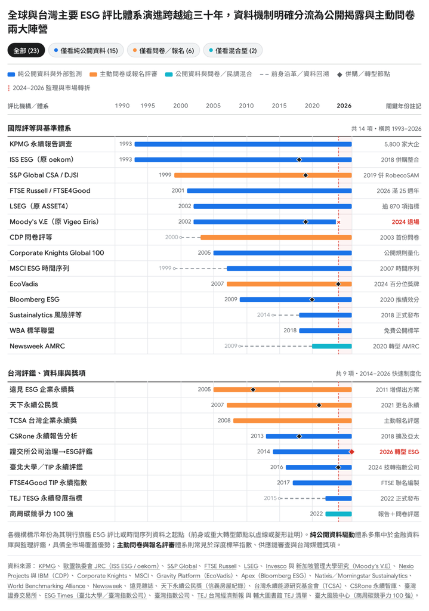

圖 1 全球與台灣主要 ESG 評比體系演進時間軸（Gemini Deep Research 生成圖）

## 一、國際 ESG 評等、資料機構與永續基準

國際永續評估市場歷經二十餘年併購整併，逐步形成以大型金融資訊商與指數公司為核心的產業結構，外圍則搭配供應鏈審查、氣候專題問卷、非營利系統轉型與商業媒體排名 [14]。本節先剖析 13 類具代表性的評比與揭露追蹤體系，再於節末說明 GRI、SASB 與 ISSB 等上游報導準則制定者的角色。

### 1. 資本市場核心 ESG 評等與資料庫

#### MSCI ESG Ratings

MSCI ESG Ratings 是全球機構投資人與被動式基金（ETF）追蹤資產規模最龐大的 ESG 評等體系之一 [17]。其永續指數歷史始於 1990 年早期社會責任投資指數，評等方法起源於 1999 年（後續透過整併 KLD、Innovest、IRRC 與 GMI Ratings 等機構累積而成，其中 KLD 於 2010 年納入），並自 **2007 年**起產出標準化時間序列資料 [15]。MSCI 不向企業寄發問卷，由研究團隊主動蒐集年報、永續報告書與委託書等公開文件，搭配逾 100 組政府、NGO 與模型資料庫（替代資料），並每日監控超過 3,400 個全球及在地媒體爭議來源；受評企業則可透過發行人溝通平台（Issuer Communications Portal）核對既有資料並補充公開文件連結 [20]。

在指標設計上，MSCI 明確採行**財務重大性**視角，評估企業對長期、具財務攸關性之 ESG 風險的韌性 [9]。模型架構包含 3 大支柱、10 項主題與 33 項關鍵議題（2020 年版為 35 項），但不會將全體清單套用於所有企業，改依 GICS 產業分類為各子產業挑選最具外部性與財務關聯的數項環境與社會關鍵議題（早期技術文件載明通常為 4–7 項，第三方實務解析 2024 版為 2–7 項，單項權重約 5%–30%），治理支柱則全面適用且權重至少占 33% [9]。環境與社會採「風險曝險分數 × 風險管理分數」（0–10 分）並扣除近三年重大爭議，公司治理則採 10 分起扣的扣分制；加權後依 GICS 同業標準化，輸出 AAA（領先）至 CCC（落後）七個相對等級 [9]。此架構不以 GRI 檢核清單逐條計分，僅將企業依 GRI 編製的永續報告視為公開資料來源之一 [20]。可查證來源：https://www.msci.com/data-and-analytics/sustainability-solutions/esg-ratings [18]。

#### Morningstar Sustainalytics（ESG Risk Ratings）

Sustainalytics 的源頭可追溯至 1992 年成立的加拿大 Jantzi Research，2009 年經歐洲多家永續研究機構整併並與 Jantzi Research 合併定名，2017 年獲晨星（Morningstar）入股 40%，並於 2020 年成為 Morningstar 全資子公司 [16]。其現行旗艦產品 **ESG Risk Ratings** 於 **2018 年 10 月**推出（月度歷史存檔自 2018 年底起，另有 2014–2017 年模擬歷史模型資料），截至 2022 年 9 月涵蓋全球 12,197 家企業，採滾動年度更新 [27]。資料來源以企業公開揭露、專屬研究與嚴格的媒體爭議追蹤（Controversy Research）為主，輔以企業檢視回饋 [1]。

與多數「高分代表績優」的同業相對評等不同，Sustainalytics 衡量的是**未管理 ESG 風險（Unmanaged ESG Risk）**，採開放式絕對量表（0 分起跳，95% 企業低於 50 分），**分數越低代表風險越小**，並劃分為可忽略（0–9.99）、低（10–19.99）、中（20–29.99）、高（30–39.99）及嚴重（40 以上）五個風險等級 [1]。架構由公司治理、產業別重大 ESG 議題（MEIs）及個別突發爭議三大構件構成（2024 年 5 月起將公司治理的計算邏輯對齊其餘 MEI），各議題皆以「曝險」與「管理」雙構面分解可管理、已管理與未管理風險；憑藉「風險單位等值原則」，投資人可直接跨產業比較不同公司的絕對風險大小 [1]。該系統設有細項指標評估準則，但不對照 GRI 清單逐題評分 [1]。可查證來源：https://www.sustainalytics.com/ [30]；方法論摘要：https://www.sustainalytics.com/docs/default-source/default-document-library/sustainalytics_esg-risk-ratings_methodology-abstract.pdf?sfvrsn=5b778b7f_8 [1]。

#### S&P Global CSA 與道瓊永續指數（DJSI / DJBIC）

標普全球企業永續評比（S&P Global Corporate Sustainability Assessment, CSA）始於 **1999 年**，原由瑞士永續投資機構 RobecoSAM 執行並作為道瓊永續指數（DJSI）的選股骨幹，2019 年 11 月由 S&P Global 收購其 ESG 評等業務 [14]。近年標普道瓊指數（S&P DJI）已將原 DJSI 系列逐步更名為 **Dow Jones Best-in-Class Indices（DJBIC）**，但選股依據仍為每年執行的 S&P Global CSA Score（2023 年 9 月前稱 S&P Global ESG Score） [34]。

CSA 在國際資本市場評等中以**高度結構化的線上深度問卷**為特色：每年橫跨 61–62 個產業，向受邀企業發出約 80–100 題跨產業與產業專屬題組（涵蓋經濟與治理、環境、社會三大面向約 20 項準則） [32]。依外部顧問指南整理，CSA 題型結合量化數據、質化政策與佐證連結，並依題目區分為「強制公開揭露」、「鼓勵公開揭露」與「接受非公開內部文件」三種給分規則 [39]。計分採極細緻的**逐題計分**與產業專屬權重加總（0–100 分），以財務重大性為核心（部分實務指引亦指其兼採雙重重大性觀點），並搭配每日監控的媒體與利害關係人分析（MSA）對重大爭議扣分 [35]。在指數篩選上採同業最佳（Best-in-Class）原則，DJSI World 僅納各產業前 10% 企業；據《天下雜誌》統計，2024 年台灣共有 42 家企業入選 DJSI 世界與新興市場指數，家數高居全球第二，僅次於美國 [32]。CSA 並非照搬 GRI 清單，但與 CDP、永續報告架構及 DE&I 認證（如 EDGE）高度接軌，跨年資料累積逾 25 年，唯題目與權重每年隨趨勢調整 [32]。可查證來源：https://www.marketplace.spglobal.com/en/solutions/corporate-sustainability-assessment-(68cedf2a-d83d-490d-93f8-134279282e29) [31]；指數方法論：https://www.spglobal.com/spdji/en/documents/methodologies/methodology-dj-bic-indices.pdf [35]。

#### LSEG ESG Scores（原 Refinitiv / Thomson Reuters ASSET4）

倫敦證券交易所集團（LSEG）的 ESG 評分系統源自瑞士資料庫 ASSET4，歷經 Thomson Reuters 與 Refinitiv 整合至 LSEG，提供回溯至 **2002 年**的長序列資料，目前官方揭露覆蓋全球逾 16,000 至 17,000 家公開與私營企業 [41]。資料來源完全仰賴企業公開揭露（年報、永續報告書、官網、交易所申報）與全球媒體爭議報導，不向企業發送問卷（外部學術整理指出其由逾 600 名內容研究分析師採四階段品管蒐集） [43]。

在傳統核心模型中，LSEG 從逾 630–870 項原始資料點篩選出 186 項具產業可比性與重大性的指標（區分布林值 Yes/No 與數值型，未揭露布林值預設給 0），歸納為資源使用、排放、創新、勞動力、人權、社區、產品責任、管理、股東、CSR 策略等 10 大類別 [42]。其計算核心為**百分位數相對排名（Percentile Rank）**（環境與社會在 TRBC 產業組內比較，治理在公司註冊國內比較），再乘上動態重大性矩陣（1–10 級權重，隨產業揭露成熟度動態調整）得出 0–100 分與 D- 至 A+ 等級 [42]。另透過 ESGC（ESG Combined Score）從 23 項媒體爭議類別評估負面事件（並按公司市值調整大型股較易受媒體關注的偏差），當爭議分數低於 ESG 分數時取兩者平均折減 [43]。LSEG 近年亦推出重新設計的模組化「LSEG ESG Scores and Data／ESG Scores Plus」（精選 170 項高標準化指標與 23 項轉型路徑管理品質氣候指標），並承諾於 2026 年向歐盟 ESMA 申請評等授權 [44]。跨年研究須留意：學界（Berg, Fabisik & Sautner, 2021）曾實證揭露 Refinitiv 歷史評分出現過大規模回溯重寫，若用於歷史回測應嚴格確認資料版本 [48]。可查證來源：https://www.lseg.com/en/data-analytics/sustainable-finance/sustainability-ratings-and-data [44]；方法論文件：https://www.lseg.com/content/dam/data-analytics/en_us/documents/methodology/lseg-da-esg-scores-methodology.pdf [43]。

#### Bloomberg：ESG Disclosure Score 與 Bloomberg ESG Scores

彭博（Bloomberg）在終端機上提供兩套常被外界混用的自有指標，均完全建構於**公開可得之企業揭露資料**，不採問卷、不與企業私下議合，且明確排除分析師主觀意見 [10]。

第一套為 **2009 年**推出的 **Bloomberg ESG Disclosure Score（0–100 分）**，純粹衡量企業公開揭露 ESG 資料點的「完整度與廣度」，未揭露欄位即留白，依該產業相關指標宇宙的揭露比例計分，不評價企業實質永續作為好壞 [2]。第二套則是 **2020 年**推出的 **Bloomberg ESG Scores**（覆蓋逾 12,000 家企業，提供逾 10 年歷史回溯序列），專門評估企業管理「財務重大性」風險與機會的表現（官方文件明確聲明不衡量雙重重大性中的影響重大性），參照 SASB 等準則選取逾 30 項風險因子，依自有 BECS 產業分類採規則導向定量模型計算（涵蓋正規化、極性判定、冪平均彙總，若議題僅含二元是非欄位則權重折減 80%，另乘以絕對揭露因子調整），產出 0–10 分、A–G 級距、0–100 百分位及跨產業可比的零中心化分數（Zero-Centered Scores） [10]。配合歐盟《ESG 評等規章》於 2026 年 7 月生效，Bloomberg 透過愛爾蘭註冊的 Bloomberg Scores Europe Limited（BSEL）發行評等，並公開聲明分數計算不使用 AI（僅於部分資料蒐集與溫室氣體估算模型中使用 AI 或機器學習輔助） [10]。兩套指標皆未以 GRI 清單逐條檢核，但高度依賴公開報告書揭露的數據 [2]。可查證來源：https://professional.bloomberg.com/products/bloomberg-terminal/sustainable-finance/scores/ [50]；方法論 PDF：https://professional.bloomberg.com/globalassets/professional/products/bloomberg-terminal/sustainable-finance/scores/bloomberg-esg-scores-methodology.pdf?v=639069475520000000 [49]。

#### ISS ESG（原 oekom research，現隸屬 ISS STOXX）

ISS ESG 的旗艦企業評等源自德國 **oekom research**（成立於 **1993 年**），2018 年由機構股東服務公司（ISS）收購，現整合於 ISS STOXX 平台，企業評等覆蓋約 8,600 家公司 [55]。資料來源以公開資訊為主，輔以全球產業分析師研究、媒體爭議監測與持續的發行人對話回饋 [58]。

其 **Corporate Rating** 採 12 級距（D- 至 A+），並可換算為 0–100 的跨產業績效分數；系統自約 700–800 項指標庫中為每個產業挑選約 100 項指標（約九成為產業專屬），並界定 4–5 項關鍵議題（合計權重逾 50%） [60]。與偏向常態分布的同業相對排名不同，ISS ESG 強調**絕對績效門檻**：得分高於該產業風險對應之 **Prime 門檻**（多數產業為 C+，高風險產業為 B-，較低風險產業為 C）方獲授 Prime Status 資格 [60]。此外，ISS 亦獨立提供側重治理與揭露風險的 QualityScore（1–10 分，1 為最低風險）以及 SDG Impact Rating（-10 至 +10） [62]。其指標設計參考 UN SDGs、GRI 與 SASB 並採透明逐項計分 [60]；評等維持年度更新，惟商業資料庫最早可追溯之完整時間序列起始年份於公開文件中未明載（未查證）。可查證來源：https://www.iss-stoxx.com/research-advisory/sustainability-ratings/ [63]；方法論入口：https://www.issgovernance.com/esg/methodology-information/ [64]。

#### Moody's ESG Solutions（原 Vigeo Eiris / V.E）：整併與退場案例

法國 Vigeo 成立於 **2002 年**，2015 年 10 月與英國 EIRIS（EIRIS 確切創立年份未查證）合併為 Vigeo Eiris（V.E），並於 2019 年 4 月獲穆迪（Moody's）收購多數股權 [14]。過往 Moody's／V.E 以公開資訊為主，採 E/S/G 平衡加權計算 0–100 分（60 分以上為 Advanced 等級），兼顧風險曝險與外部營運影響 [16]。但在產業競爭與歐盟監理趨嚴下，Moody's 已於 **2024 年 7 月 1 日**宣布與 MSCI 締結策略夥伴關係，**正式關閉自有 ESG Solutions 評等業務**；多檔原本採用 Moody's ESG 資料的歐洲永續 ETF 已於 2025 年 4 月完成轉換，改用 MSCI ESG 資料 [12]。此一轉折代表該評等體系已停止跨年更新，僅留存歷史資料 [12]。可查證來源：https://ir.moodys.com/press-releases/news-details/2024/Moodys-and-MSCI-Announce-a-Strategic-Partnership-to-Enhance-Transparency-and-Deliver-Data-Driven-Risk-Solutions/default.aspx [69]。

#### FTSE Russell（FTSE ESG Scores 與 FTSE4Good 指數系列）

富時羅素（FTSE Russell，現屬 LSEG 集團）於 **2001 年**推出全球最早一批永續基準指數之一的 **FTSE4Good 指數系列**（2026 年邁入第 25 週年） [70]。其資料政策立場鮮明：**明確不發送企業問卷**，主張僅以公開揭露（年報、永續報告書、公司網站、新聞稿，並輔以 CDP 氣候資料與公開統計）可減少自評偏差並確保來源完全可追溯；但於年度評核週期中，會透過線上平台給予企業約四週檢視與補充公開連結的回饋窗口 [72]。

模型採規則導向（rules-based）的四層架構：3 大支柱、14 項主題（環境 5 項、社會 5 項、治理 4 項，對應全部 17 項 UN SDGs）、逾 300 項指標（每家公司平均適用約 125 項） [70]。計分核心為**曝險加權機制**：先依產業與營運地判定各適用主題的曝險等級（1 低至 3 高），再依逐項指標得分率換算 0–5 分（高曝險企業的得分門檻更嚴格），最後以主題曝險度作為權重彙總支柱分數與總分（0–5 分），並結合菸草、燃煤、爭議性武器排除規則與爭議監測決定 FTSE4Good 成分股資格 [70]。該模型未逐條照搬 GRI 清單，但高度仰賴永續報告書公開數據，並累積逾二十年的跨年紀錄 [70]。可查證來源：https://www.lseg.com/en/ftse-russell/indices/ftse4good [70]；方法論 PDF：https://www.lseg.com/content/dam/ftse-russell/en_us/documents/policy-documents/ftse-russell-esg-data-model-methodology.pdf [72]。

### 2. 專題問卷、供應鏈評等、非營利基準與媒體排名

#### CDP（原碳揭露專案）

CDP 為 2000 年成立於英國的非營利組織，自 **2003 年**起代表機構投資人與跨國買主發出首份碳揭露問卷，目前透過 CDP 揭露的企業已占全球近三分之二市值 [75]。CDP 專注於**環境面向（E）**：2024 年起將原有氣候變遷、水安全與森林三份獨立問卷整合為單一「整合式企業問卷」，並擴及塑膠、生物多樣性與海洋議題（2026 年此三項新議題暫不計分；另設中小企業專屬 SME 問卷並於 2026 年導入氣候 A 級評分） [78]。

CDP 採公開透明的**逐題計分與四階梯晉級制**：分為揭露（D-/D）、認知（C-/C）、管理（B-/B）與領導力（A-/A），未回覆則給 F [75]。其關鍵規則是**必備條件（Essential Criteria）**：企業須同時達到該階層分數門檻並滿足所有必備條件方能晉級（以 2023 年氣候變遷評分方法論為例，角逐 A 級須提交公開回覆、範疇一與二 100% 查證、至少一項範疇三類別 70% 查證，並具備董事會監督的 1.5°C 轉型計畫）；題組另含表格比例計分與跨題誤差 5% 檢核 [80]。CDP 官方明確指出，其分數衡量的是「揭露品質與環境管理成熟度」，而非絕對環境績效 [80]。其架構主軸對齊 TCFD、IFRS S2、GHG Protocol 與 SBTi（非以 GRI 清單為主，2026 年增設跨準則標示），具自 2003 年起的跨年資料，但各年度門檻持續上調 [78]。可查證來源：https://www.cdp.net/en/disclosure-2026 [78]；評分說明：https://help.cdp.net/en-us/knowledgebase/article/KA-01160 [80]。

#### EcoVadis

創立於 **2007 年**、總部位於巴黎的 EcoVadis，是全球最具規模的**供應鏈企業永續商業評等平台**，官方數據顯示累計受評企業逾 15 萬家（第三方顧問文章估計已達 17.5 萬家），橫跨逾 180 國，廣泛為跨國品牌買主用於供應商盡職調查 [85]。EcoVadis 採企業付費訂閱制，依產業、員工人數規模（特小至大型四級）與營運地風險客製化線上問卷，並**嚴格要求檢附具日期的正式佐證文件**（單純文字作答而無文件佐證不予計分），再結合 **360° Watch**（監測逾 10 萬個外部新聞、法規與觀察名單來源），由分析師審核 6–8 週產出效期 12 個月的記分卡 [85]。

評核架構分為環境、勞工與人權、商業倫理、永續採購四大主題共 **21 項永續準則**，明確建構於 GRI、ISO 26000 與聯合國全球盟約（UNGC）等標準 [86]。每個主題透過政策、倡議背書、措施、認證、覆蓋率、揭露報告及 360° 監測七項管理面向以公開公式計算 0–100 分，再依產業權重加總為總分 [89]。2024 年起，獎牌改採「過去 12 個月全體受評企業動態百分位」：白金（前 1%）、金（前 5%）、銀（前 15%）、銅（前 35%），且四主題皆不得低於 30 分；據第三方顧問機構整理，因母體逐年進步，2022 年 75 分即可獲白金，至 2026 年 65 分僅達銅牌門檻 [85]。可查證來源：https://support.ecovadis.com/hc/en-us/articles/115002531507-What-is-the-EcoVadis-methodology [91]；2026 公開方法論 PDF：https://ecovadis.com/wp-content/uploads/2026/04/EcoVadis-Sustainability-Rating-Methodology-disclosure-document-for-the-public-rating-users-and-rated-items.pdf [89]。

#### World Benchmarking Alliance（WBA，世界基準聯盟）

WBA 為 **2018 年**成立的非營利組織，鎖定全球最具系統影響力的 2,000 家關鍵企業（**SDG2000**，涵蓋上市、私營與國營企業，合計產值約當全球 GDP 的 48%） [3]。WBA 堅持**免費公開所有基準報告與方法論**，資料來源嚴格限定為**公開可得資訊**（原則以英文公開文件為主，回饋期間可補附可連結之原文翻譯），不收費亦不採封閉問卷 [3]。

在方法哲學上，WBA 刻意區隔於主流財務風險評等，明確以影響重大性（Impact Materiality）為核心，檢驗企業如何透過核心業務驅動氣候、自然、人權、性別、糧食、數位與金融七大系統轉型以達成 UN SDGs，近年並整合推出「整合轉型評估（ITA）」 [3]。其指標採公開逐項元素計分與情境式評分原則（Contextual scoring）：僅簽署倡議不足以構成證據，且對永續發展具實質負面衝擊的業務，即便形式揭露亦不給分 [3]。其架構對齊 UN SDGs 與國際人權準則而非 GRI 清單，採定期輪動更新並於 2026 年提供統合企業記分板 [93]。可查證來源：https://www.worldbenchmarkingalliance.org/ [93]；組織使命：https://www.worldbenchmarkingalliance.org/about-us/our-mission [92]。

#### Corporate Knights（Global 100 全球百大永續企業）

加拿大研究與媒體機構 Corporate Knights 自 **2005 年**起每年公布「Global 100 全球百大永續企業」，評估母體為年營收超過 10 億美元之全球上市公司，完全依據公開財報、永續報告書與網站資料評比，不需企業報名或付費（事前會通知確認公開資料） [97]。

其方法論主打高度透明、規則驅動並揭露企業「說做落差（say–do gap）」，不以數百項 GRI 條文計分，直接聚焦企業核心營收與資本配置 [97]。依 2026 年最新方法論（永續經濟分類標準 V9.0），評分核心由三大 KPI（包含依開源《Corporate Knights 永續經濟分類標準》計算之**永續營收比率**與**永續投資／資本支出比率**；第三項核心 KPI 名稱於現有檢索摘錄中未完整列出，標明未查證）、一項加分指標（CEO 變動薪酬與永續目標掛鉤比率），以及兩項最高各扣 5% 的扣分項（重大罰款與和解金占營收比、員工職災死亡率）構成，並排除永續營收低於 3%、涉足武器／菸草或阻撓氣候政策遊說之企業 [99]。該機構提供自 2005 年起逾 20 年的歷年百大資料集，惟指標設計隨時代大幅精簡重構 [100]。可查證來源：https://corporateknights.com/rankings/global-100-rankings/ [98]；2026 方法論 PDF：https://corporateknights.com/wp-content/uploads/2026/01/2026-01-05-2026_CK_Ratings_methodology.pdf [99]。

#### Newsweek 等國際媒體排名與 KPMG 揭露趨勢追蹤

國際媒體永續排名以美國《Newsweek》最具知名度。其早年於 **2009 年**推出「Green Rankings」（運作至 2017–2018 年間），**2020 年**起轉與市調機構 Statista 合作發布「America's Most Responsible Companies（美國最負責任企業，AMRC）」，近年亦增設「World's Greenest Companies」等榜單 [101]。AMRC 採**公開 KPI 與獨立公眾民調混合制**：從美國逾 2,000 家大型企業初篩後，蒐集 CSR／永續報告書中逾 30 項 E/S/G 指標（涵蓋碳排／水／能源／廢棄物強度、減量聲明、SBTi 與 CDP 參與、董事會多元性、工安事故率、離職率與人權政策等），再結合線上問卷調查民眾對企業責任的觀感，計算 0–100 綜合分數選出前 400–600 名（上榜企業可向 Statista 付費取得標章授權） [101]。此類媒體排名不對照 GRI 檢核清單，且因揉合主觀公眾認知與年度入選名額變動，跨年計量嚴謹度相對有限 [102]。可查證來源：https://rankings.newsweek.com/americas-most-responsible-companies-2025 [101]；方法論 PDF：https://d.newsweek.com/en/file/462268/americas-most-responsible-companies-2022-methodology.pdf [102]。

此外，KPMG 全球永續報告大調查（Survey of Sustainability Reporting）自 **1993 年**起定期執行，2024 年版審閱全球 58 國／地區前百大企業（N100，共 5,800 家）與全球前 250 大企業（G250）之公開年報及永續報告書；雖不替個別企業排定名次，卻是追蹤全球 GRI、SASB、TCFD、IFRS S2、雙重重大性與第三方確信採用趨勢最悠久的跨年基準（2024 年調查顯示 96% G250 與 79% N100 已揭露永續資訊，約四分之三 G250 企業仍採用 GRI） [108]。可查證來源：https://kpmg.com/xx/en/our-insights/sustainability/the-move-to-mandatory-reporting.html [108]。

### 3. 上游準則制定單位的角色：GRI、SASB 與 ISSB

在全球 ESG 資訊鏈中，**GRI、SASB 與 ISSB 屬於「報導準則制定者」，並非評等或排名機構** [6]。它們界定了企業揭露永續資訊的共通語言與邊界，直接決定下游評等機構與學術研究能否取得具可比性的原始資料 [7]。

GRI（全球永續性報告協會）於 **1997 年**在美國波士頓成立（秘書處 2002 年設於荷蘭阿姆斯特丹），2000 年發布首版指引，2016 年轉型為模組化 GRI Standards，並於 2021 年全面改版（2023 年 1 月生效），確立通用準則（GRI 1/2/3）、行業準則與主題準則（200 經濟、300 環境、400 社會，後續增訂 GRI 101 生物多樣性、GRI 102 氣候變遷等） [8]。GRI 的核心在於影響重大性（Impact Materiality）與多方利害關係人導向，要求企業說明營運對經濟、環境與人群（含人權）的實質衝擊與管理方針 [6]。在台灣，金管會規範上市櫃公司編製永續報告書須依循 GRI 準則，使其成為台灣企業最核心的永續報告架構 [111]。可查證來源：https://www.globalreporting.org/about-gri/who-we-are/ [113]。

相較之下，**SASB（永續會計準則委員會）**（2022 年 8 月起由 IFRS 基金會旗下 ISSB 承擔職責；註：SASB 原始創立年份於本報告所檢索公開文件記載不一，部分本土資料庫標註 2001 年而未獲官方文件佐證，標明未查證）與 **ISSB（國際永續準則理事會，2021 年底成立）則站在投資人與資本市場視角**，採取財務重大性（Financial Materiality）原則 [6]。SASB 為 77 個產業制定高度標準化的量化指標；ISSB 則於 2023 年 6 月正式發布 **IFRS S1**（永續相關財務資訊一般揭露）與 **IFRS S2**（氣候相關揭露），吸收已結束運作的 TCFD 架構並以 SASB 產業指標為重要參考 [6]。據外部準則比較整理，截至 2026 年 4 月已有 28 個司法管轄區以不同形式採納 ISSB 準則，台灣金管會亦規劃自 2026 至 2028 會計年度分三階段於年報永續專章接軌 [7]。2025 年 6 月，GRI 與 IFRS 基金會並就溫室氣體（GRI 102 與 IFRS S2）達成互通對等，使「GRI 向外看衝擊、ISSB／SASB 向內看財務」逐漸形成互補的雙重重大性積木架構 [6]。可查證來源：https://www.ifrs.org/news-and-events/news/2023/06/issb-issues-ifrs-s1-ifrs-s2/ [117]。

## 二、台灣 ESG 評鑑、本土資料庫與永續獎項

台灣的企業永續評估環境兼具「監理機關強力引導」、「本土量化資料庫普及」與「媒體及民間基金會獎項蓬勃」三大特徵。自 2025 年起，金管會強制全體上市櫃公司（包含實收資本額 20 億元以下者）全面編製並申報永續報告書，加上 2026 年公司治理評鑑正式轉型為 ESG 評鑑，台灣資本市場的永續揭露已從「求有」邁入「深化品質與資料治理」的關鍵階段 [13]。

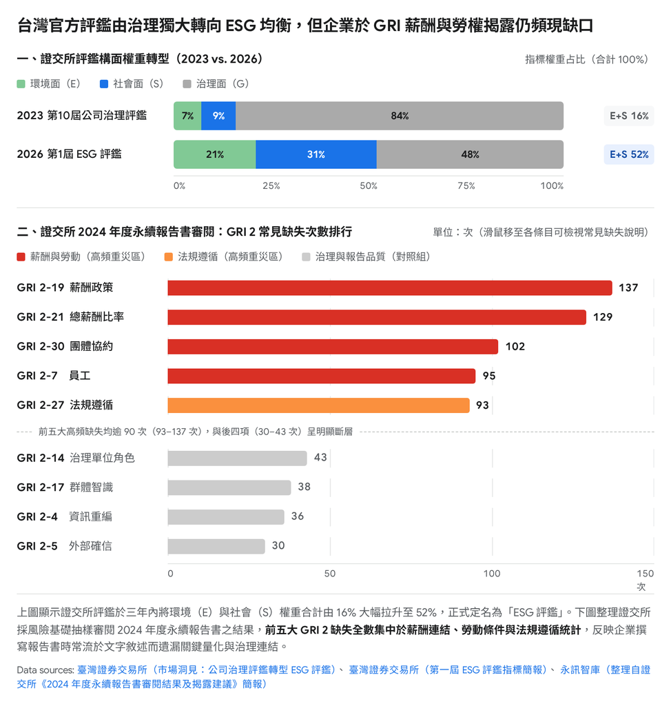

圖 2 證交所評鑑構面權重轉型與 2024 年度永續報告書審閱 GRI 2 常見缺失（Gemini Deep Research 生成圖）

### 1. 臺灣證券交易所（與櫃買中心）「公司治理評鑑 → ESG 評鑑」

證交所與櫃買中心在金管會指導下，自 **2014 年度**起每年對全體上市櫃公司實施「公司治理評鑑」，是台灣覆蓋率最全面、政策驅動力最強的官方評核制度 [4]。其運作邏輯在於「先透過評鑑指標引導企業自願實踐，成熟後再納入法令強制項目」（例如股東會電子投票、獨立董事與審計委員會、不同性別董事等皆循此途徑推動） [4]。歷經多屆循序擴充環境與社會題組後，評鑑於 **2025 年 10 月**正式更名，並自 **2026 年度（民國 115 年）起轉型為第一屆「ESG 評鑑」**，將原有四大構面重組為環境面（E）21%、社會面（S）31%、治理面（G）48%（相較 2023 年第 10 屆的 7%、9%、84%，結構大幅平衡）；兩機構並已於 2026 年 11 月公布 116 年度第二屆共 72 項修訂指標 [4]。

資料來源完全以公開資訊為準（公開資訊觀測站、年報、永續報告書及整合後的 ESG 數位平台，2026 年並精簡刪除部分公司網站與問卷揭露依據），無須企業主動報名 [4]。計分原則採「是／否（二元題型）」逐題計分，部分指標附設進階加分條件（如取得 ISO 50001 或第三方驗證另加一分），並設有重大優良實績與重大違規（如投保中心提告、重大內控缺失、主管機關重罰）的額外加減分 [120]。結果於次年 4 月底前公布，上市與上櫃分開排比為 7 個級距（對外不揭露個別公司原始得分） [4]。此評鑑並非照搬 GRI 清單，但多數環境與社會指標（溫室氣體、能源與廢棄物、人權盡職調查、友善婚育、員工離職率、TCFD／IFRS S2）與 GRI 及 IFRS 高度連動，並具自 2014 年起的跨年級距資料 [4]。可查證來源：https://cgc.twse.com.tw/front/evaluationOverview [120]；ESG 評鑑專區：https://cgc.twse.com.tw/esgEvaluation/listCh [124]；轉型專文：https://www.twse.com.tw/market_insights/zh/detail/8a8216d69bde495d019c0cf16bcb00e1 [4]。

### 2. 台灣經濟新報（TEJ）「TESG 永續發展指標」

台灣經濟新報（TEJ）於 **2022 年 3 月 31 日**正式推出「TESG 永續發展指標」，並建置回溯至 **2015 年起**的歷年構面分數與評等資料庫，是目前台灣覆蓋家數最廣、且為國內財金與會計實證研究最常採用的商業評等資料庫；截至 **2026 年 11 月**最新一期已涵蓋 **2,592 家**台灣公開發行以上企業 [114]。資料來源全數擷取自公開永續報告書、年報、財報、公開資訊觀測站、政府裁罰與新聞事件雷達，無須企業填寫問卷 [129]。

TESG 為台灣首個取得 **SASB 官方正版授權**的評等指標，其方法論融合「SASB 產業重大性架構」與「GRI 揭露完整度檢視」 [114]。架構涵蓋 E、S、G 三大支柱與 **16 項主題**（環境 5 項、社會 6 項、公司治理 5 項），將可量化變數與資訊揭露程度標準化加權為 0–100 分，再對應為 **A+、A、B+、B、B-、C、C- 七個等級**（分領先、平均、落後三群組） [126]。2026 年 11 月更新更正式導入「W 警告評等」，針對經主管機關認定或司法程序確認涉及重大公安健康危害、詐欺隱匿或財報重大缺失之企業直接標示警告，同時開始追蹤企業提前採用 2025 年版 GRI 能源與氣候準則的情形 [125]。TESG 屬多變數標準化量化模型而非人工打勾清單，每年定期發布兩次（約 5–6 月與 11 月），具高度完整的跨年追蹤資料（Panel Data） [125]。可查證來源：https://www.tejwin.com/solution/esg-solution/ [129]；2026 評等發布公告：https://www.tejwin.com/news/tesg%E6%B0%B8%E7%BA%8C%E7%99%BC%E5%B1%95%E6%8C%87%E6%A8%99-2026%E5%B9%B4%E6%9C%80%E6%96%B0%E7%AD%89%E7%B4%9A%E7%99%BC%E5%B8%83/ [125]。

### 3. 臺灣指數公司（TIP）永續指數與「TIP 台灣永續評鑑」（SEED 模型）

臺灣證券交易所全資子公司臺灣指數公司（TIP）在台灣永續投資與評鑑體系採取雙軌布局：

第一軌是與國際指數商合編的 **FTSE4Good TIP 臺灣永續指數**，於 **2017 年 12 月 18 日**正式發布（基期 2017 年 6 月 16 日），以 FTSE4Good 新興市場指數中之台灣上市公司為合格母體（直接套用 FTSE Russell 14 主題、逾 300 項指標模型），再經財務指標篩選編製，並授權發行「元大臺灣 ESG 永續 ETF（00850）」與臺灣永續期貨等商品 [136]。可查證來源：https://taiwanindex.com.tw/indexes/f4gtte [136]。

第二軌則是與學術界深度結合的 **「TIP 台灣永續評鑑」（SEED 模型）**。該模型原由國立臺北大學商學院企業永續發展研究中心（池祥麟教授團隊）自 **2016 年**起建構，2020 年起與臺灣指數公司合作模組化並陸續推出逾 11 檔永續指數（授權發行 00923 群益台灣 ESG 低碳 50、00928 中信上櫃 ESG 30 等多檔 ETF），於 **2024 年 7 月**正式簽約將技術移轉予臺灣指數公司，並於 2025 年邁向全面涵蓋上市櫃公司 [140]。

SEED 模型在方法上最接近嚴謹的**公開報告書逐題計分法**：完全仰賴公開資料（永續報告書、年報、官網、政府環保等裁罰資訊），獨創 **SEED 四大構面**：社會（Social）、經濟與治理（Economic）、環境（Environmental）及獨立的揭露（Disclosure）構面，細分為 **22 類次構面、92 類子分類、325 類題項**，並針對金融、電子、製造、服務四大產業設計共同題與差異題 [142]。計分同時包含正向題與負向扣分題（例如重大環保裁罰最高扣 3 分，且修訂刪除純質化環境目標給分、加重溫室氣體量化目標配分），最後以總得分除以該產業最高可能總分得出標準化百分比得分率與 A–AAA 等級 [142]。模型緊密接軌 GRI、CDP、PBAF 等國際規範與台灣政策，累積自 2016 年起的跨年資料庫（2021 年 561 家、2022 年 658 家，2025 年擴及全體上市櫃） [140]。可查證來源：https://irengage.taiwanindex.com.tw/news?id=14 [141]；SEED 方法論簡報：https://dsp.tpex.org.tw/storage/csr/%E5%BE%9E%E5%84%AA%E7%A7%80%E5%88%B0%E5%8D%93%E8%B6%8A%EF%BC%9A%E6%8F%90%E5%8D%87%E4%BC%81%E6%A5%ADESG%E8%A9%95%E5%88%86-%E4%BB%A5%E5%8F%B0%E7%81%A3%E6%B0%B8%E7%BA%8C%E8%A9%95%E9%91%91%E7%82%BA%E4%BE%8B.pdf [142]。

### 4. 媒體與民間基金會永續獎項：天下、遠見與 TCSA

台灣的民間永續獎項對企業形象與高層重視度影響極深，但三者皆屬「企業主動報名＋付費參賽＋問卷或專案書審＋專家評審」模式，與前述全市場公開資料庫在樣本代表性與客觀結構上有根本區隔。

#### 天下雜誌「天下永續公民獎」與「天下永續公民評鑑」

《天下雜誌》自 **2007 年**獨立創辦「天下企業公民獎」（最初評選 TOP 50，2015 年擴至 TOP 100，2021 年更名「天下永續公民獎」；2023 年增設「天下人才永續獎」，2024 年起與《康健》共同辦理「CHR 健康企業公民獎」） [145]。本土企業報名須符合「過去 3 年內至少 2 年本期淨利為正」資格（外商、醫院與非營利組織不限），並繳交報獎費新台幣 25,000 元 [147]。架構分為「公司治理、企業承諾、社會參與、環境永續」四大構面共 22 大主題，分兩階段評選：初選由《天下》調查中心針對問卷量化題組依「Net Positive（淨正效益）」原則**逐題計分**（僅符合法定低標最多 1 分，主動超越法規並展現營運外正向影響力方得 2–3 分；該量化題組並獨立發展為「天下永續公民評鑑」健檢）；決選則邀各界專家評審團依產業與規模分組審閱專案及量化數據，並排除重大爭議企業 [146]。題組參考 DJSI、GRI 與 SDGs，非逐條檢核 GRI 報告書，歷年百強榜單自 2007 年延續至今，但僅涵蓋主動報名且具獲利者 [145]。可查證來源：https://csr.cw.com.tw/esgaward/article/1002 [147]；2026 評選指南：https://csr.cw.com.tw/survey/2026ESG/guidebook.pdf [146]。

#### 遠見雜誌「遠見 ESG 企業永續獎」

《遠見雜誌》於 **2005 年**首創華人媒體最早的企業社會責任大調查（現稱「遠見 ESG 企業永續獎」，2011 年增設「傑出方案」專案競賽，2025 年第 21 屆正式開放醫療機構類） [152]。採主動付費報名（每件新台幣 15,750 元），角逐「綜合績效」者須近兩年無稅後虧損 [153]。賽制雙軌並行：綜合績效類分六組依 E、S、G 架構評核策略規劃、利害關係人議合、揭露透明度與組織績效，選出首獎與楷模獎並公布 Top 10–Top 50 榜單（三連霸首獎企業納入年度榮譽榜免再角逐三屆）；傑出方案類則分八組評選單年度專案創新 [153]。評選標準結合 DJSI、CDP、GRI、TNFD、SASB 理念，歷屆平均得獎率約二至三成，但內部詳細逐題配分表未完全對外公開（未查證），且具自願報名選擇性 [153]。可查證來源：https://csr.gvm.com.tw/ [153]；活動官網：https://event.gvm.com.tw/esg/ [155]。

#### 台灣永續能源研究基金會（TAISE）「TCSA 台灣企業永續獎」

TCSA 為台灣參賽家數最龐大的民間永續獎項（第三方顧問整理 2024 年時累計參賽企業已達 731 家） [156]。關於開辦年份，TAISE 培訓簡章載明自 **2008 年**起舉辦（與 2026 年為第 19 屆吻合），而官網獎項總覽頁另載「自 2007 年開辦」，謹並陳兩處官方記載 [157]。參賽採付費審查（每單位報名費 25,200 元，各獎項審查費另計 15,000–25,200 元），設四大獎項：永續綜合績效（選出製造業與服務業十大、百大永續典範企業等；台灣企業須同步報名報告獎且報告書通過第三方保證／確信，並提交 5,000 字書面說明與決選簡報）、永續單項績效（E/S/G 共 15 項領袖獎）、**永續報告獎**（2026 年以營收 150 億元區分兩類，依「報告內容 60%（完整性 40%、可信度 35%、溝通性 25%」與「多元媒體應用及官網專區 40%」評定白金、金、銀、銅四級），以及永續傑出人物獎 [158]。TCSA 訂有構面與效標配分表（如綜合績效八大構面共 24 項效標），由評審團逐項效標給分，且高度要求對齊 GRI Standards、IFRS S1／S2 與 TNFD；歷年得獎紀錄完整，但受限於付費報名與專家評審主觀性，較適合作為標竿觀察而非全市場學術計量變數 [158]。可查證來源：https://tcsaward.org.tw/tw/about/selection/TCSA [158]；簡章 PDF：https://tcsaward.org.tw/uploads/files/2025/2025_tcsa_guideline.pdf [160]。

### 5. 商業徵信與專題研究團隊：中華徵信所、商周×臺大、CSRone×政大與資誠×成大

#### 中華徵信所（CRIF 台灣）「Synesgy 平台與 CRIF Synesgy Ratings」

中華徵信所自 **1970 年**起編製台灣歷史最悠久的財務規模排名「TOP 5000 大型企業排名」 [163]。併入義大利 CRIF 集團後，在台導入集團全球 ESG 供應鏈數位平台 **Synesgy**（台灣確切上線年份未查證；全球累計逾 1,500 家品牌買主使用、逾 58 萬家供應商註冊，在台並與台灣經貿網及台新銀行等合作供應鏈評估與綠色融資） [165]。Synesgy 採企業線上自評問卷模式，依產業客製化題組逐題計分並產出 ESG 分數、產業比較基準、改善計畫與永續標章證書（細部等級區間劃分於台灣公開網頁中未詳列，標明未查證） [165]。其問卷對齊 GRI、UNGC、CDP 與歐盟 ESRS，並已於 **2024 年取得 GRI 正式認證**；CRIF 集團總部亦成立專責評等公司 **CRIF Synesgy Ratings**，結合徵信資料與 AI／雲端技術因應歐盟 2026 年 ESG 評等監管 [166]。在台是否已建置上市公司公開跨年長序列尚未見公開說明（未查證），實務上更偏重供應鏈盡職調查與銀行授信工具 [165]。可查證來源：https://www.credit.com.tw/NEWcreditonline/Synesgy/ [165]；評等公司成立公告：https://www.tw.crifasia.com/newsroom/crif-news/synesgy-ratings/ [169]。

#### 《商業周刊》× 臺大風險中心「碳競爭力 100 強」

自 **2022 年**起由《商業周刊》與國立臺灣大學風險社會與政策研究中心合作辦理，是台灣少數將「碳排數據」與「企業營收財務效率」直接掛鉤的年度專題排名 [173]。調查自全體上市公司中篩選「連續三年上傳永續報告書且載有完整、標準一致碳排資料」者（2025 年樣本擴增至 582 家），結合公開碳排數據與問卷調查，依碳排減少率、碳生產力（每噸碳創造之營收）、減碳承諾、決策層級（5%）與範疇三揭露（5%）等五大指標按產業比例選出百強，並直接排除當年度遭環境部列管裁罰逾新台幣 100 萬元之企業 [173]。此排名不對照完整 GRI 清單，但具四年連續追蹤與強烈的減碳鑑別力（四年間僅 24 家企業連續上榜） [173]。可查證來源：https://rsprc.ntu.edu.tw/web/news/video_in.jsp?lang=tw&np_id=NP1763710110460 [173]。

#### CSRone 永續智庫 × 政治大學信義書院《臺灣暨亞太永續報告現況與趨勢》

自 **2013 年**起每年發布（2016 年政大商學院信義書院加入研究團隊，2018 年擴展分析亞太 10 國／地區市值前 10 大企業；至 2025 年初累計蒐錄逾 7,100 本報告） [177]。該團隊不對個別台灣企業排定名次，主要以大規模永續報告書內容盤點為核心，系統統計台灣企業對 GRI、SASB、TCFD、SDGs 的採用狀況、前十大重大主題演變、董事會監督比率、淨零目標與人權盡職調查深度，並計算亞太 10 國整體揭露評分（台灣於 2022–2024 年連續三年居冠，2024 年達 77.1%） [177]。可查證來源：https://csrone.com/reports/6813 [177]。

#### 資誠（PwC Taiwan）× 成功大學 FinTech 商創研究中心與證交所審閱機制

因應台灣全面強制編製永續報告書後的資訊可信度議題，資誠與國立成功大學 FinTech 商創研究中心自 **2024 年**起合作發布《永續資訊確信市場觀察報告》，統計全體上市櫃公司（2025 年計 1,887 家發布 2024 年度報告書）取得第三方確信或查證的比例（整體 43%、非強制產業自願確信 38%）與確信標的分布，並引用會計文獻解析確信機制的「聲譽保險效果」 [118]。另一方面，**臺灣證券交易所**本身除辦理 ESG 評鑑外，亦執行以風險為基礎（RBA）的年度**永續報告書審閱**，逐項檢核 GRI 2、GRI 3 與氣候附表缺失，並透過 ESG 數位平台（已整合 102 項 ESG 指標）與 AI 擷取年報工具，推動台灣永續報告走向機器可讀的跨年比較資料庫 [111]。可查證來源：https://www.pwc.tw/zh/publications/topic-sustainability/assets/sustainability-related-assurance-market-observation-report.pdf [118]；證交所審閱解析：https://www.sustaihub.com/blog/%E8%AD%89%E4%BA%A4%E6%89%802024%E5%B9%B4%E5%BA%A6%E6%B0%B8%E7%BA%8C%E5%A0%B1%E5%91%8A%E6%9B%B8%E5%AF%A9%E9%96%B1%E7%B5%90%E6%9E%9C%E5%85%A8%E8%A7%A3%E6%9E%909%E5%A4%A7gri%E7%BC%BA%E5%A4%B1%E8%88%87%E6%B0%A3%E5%80%99%E6%8F%AD%E9%9C%B2%E5%BB%BA%E8%AD%B0/ [111]。

## 三、學術研究團隊與永續揭露分析方法

相較於商業評等常見的黑箱權重與指標整合，國際會計、財務與管理學界過去二十餘年聚焦於三大核心課題：如何客觀量化公開永續報告書的揭露品質？如何運用自然語言處理（NLP）突破人工判讀的樣本限制？以及為何各家商業 ESG 評等的分歧如此劇烈？

### 1. 以 GRI 為檢核清單的揭露指數（GRI-based Disclosure Index）

自 GRI 2000 指引發布以來，會計與環境管理學者便發展出「以公開永續報告書逐題對照 GRI 條目計分」的經典研究典範。Morhardt, Baird & Freeman（2002）率先將 GRI 2000 與 ISO 14031 轉化為 **0–3 分**逐項數值評分系統，建立跨企業比較永續報告完整度的基礎 [182]。隨後 Skouloudis, Evangelinos & Kourmousis（2009、2010）針對 GRI 2002 的 141 項主題建立 **0–4 分**分級評分表，區分未揭露、簡要敘述、詳盡說明至系統化量化呈現 [182]；Yadava & Sinha（2016）以 GRI 2011 的 84 項績效指標（經濟 9、環境 30、社會 45）採 0–3 分評分，明確將「涵蓋超過一年之系統性跨年數據」列為滿分 3 分門檻 [182]。部分研究亦透過專家問卷對不同產業的 GRI 條目賦予差異權重（Multi-Weighted Sustainability Disclosure Checklist） [187]。

不過，學界也對此路線提出深刻警示。Michelon, Pilonato & Ricceri（2015，Critical Perspectives on Accounting）指出，單純出版獨立永續報告書、宣稱遵循 GRI 指引或取得第三方確信，未必對應更高的實質揭露品質，反而常成為企業維護社會正當性的「象徵性作為（symbolic approach）」 [188]。此類方法完全仰賴公開報告書、100% 對照 GRI 逐題計分，但因極度耗費人工，樣本數多受限於數十至兩三百家，且跨年比較易受 GRI 改版影響。可查證來源：Morhardt et al. (2002) https://ideas.repec.org/a/wly/corsem/v9y2002i4p215-233.html [184]；Michelon et al. (2015) https://ideas.repec.org/a/eee/crpeac/v33y2015icp59-78.html [188]。

### 2. Clarkson et al. (2008) 硬性／軟性揭露評分法

在所有以 GRI 為底本的學術評分工具中，Clarkson, Li, Richardson & Vasvari（2008）發表於頂尖會計期刊 Accounting, Organizations and Society 的硬性／軟性環境揭露指數最具代表性 [190]。該研究為了驗證經濟學「自願揭露理論」與社會政治「合法性理論」對績效與揭露關係的相反預測，依據 GRI 架構設計出 **45 項指標、滿分 95 分**的評分表，劃分為七大類別（A1–A7） [190]：

- **硬性揭露（Hard Disclosure，A1–A4，滿分 79 分）**：客觀、可驗證、環境績效差者難以低成本模仿的揭露，涵蓋 A1 治理結構與管理系統、A2 可信度（如第三方查證、採用 GRI）、A3 環境績效指標（依有無量化數據、跨年比較、產業標竿、減量目標分層給分）、A4 環境支出 [190]。
- **軟性揭露（Soft Disclosure，A5–A7，滿分 16 分）**：一般性宣稱與較難驗證的描述，包含 A5 願景與策略宣示、A6 環境概況、A7 環境倡議 [192]。

Clarkson 團隊將報告書評分對照美國環保署有毒物質排放清冊（TRI）等外部客觀數據，發現**環境績效較優的企業確實主動揭露顯著較多的「硬性」可驗證指標**，而績效落後者則傾向以「軟性」願景宣稱來因應外部壓力，釐清了過去文獻對績效與揭露關聯分歧的根源 [190]。後續學者如 Ong et al.（2016）更進一步將這套硬性／軟性分類擴展至 GRI 的經濟、環境與社會完整三構面 [194]。可查證來源：https://www.researchgate.net/publication/4748813_Revisiting_the_Relation_Between_Environmental_Performance_and_Environmental_Disclosure_An_Empirical_Analysis [197]。

### 3. 傳統內容分析與編碼信度檢驗（Content Analysis）

內容分析（Content Analysis）是永續報告量化評分的方法學基礎（如 Hackston & Milne, 1996），而 Milne & Adler（1999，Accounting, Auditing & Accountability Journal）則為此領域確立了嚴格的編碼信度檢驗標竿 [198]。此做法以公開年報或永續報告書中的「句子」或頁數占比為編碼單位，歸類至主題構面、證據屬性（貨幣量化、非貨幣量化、定性描述）與消息方向 [198]。Milne & Adler 透過三名不同經驗編碼員、五輪共 49 份年報的實驗發現：未受訓編碼員在加總「總揭露量」上雖可達一定一致性，但一旦進入細項子類別分析，**至少須經過 20 份報告的編碼訓練與校準**方能達到可接受的評分者間信度（Krippendorff's α），且不得以相關係數取代一致性係數 [198]。可查證來源：https://ideas.repec.org/a/eme/aaajpp/09513579910270138.html [200]。

### 4. 文字探勘、領域預訓練模型（NLP）與大型語言模型（LLM）揭露分析

2020 年代以來，為突破人工逐頁閱讀動輒數百頁報告書的規模瓶頸，跨國財金與資訊研究團隊相繼開發出三代自動化文本評分方法，可輕易擴展至數千家企業的長跨年語料：

第一代為**領域微調預訓練語言模型**。蘇黎世大學（UZH）、蘇黎世聯邦理工（ETH Zurich）與德國 FAU 團隊（Markus Leippold、Julia Bingler、Mathias Kraus、Nicolas Webersinke）開發的 **ClimateBERT（2021、2022）**，以逾 200 萬段氣候相關文本進行領域預訓練，在 Finance Research Letters 論文〈Cheap talk and cherry-picking〉中自動化掃描企業報告並建構「廉價談話指數（Cheap Talk Index）」，發現許多公開支持 TCFD 的企業其實只在治理與風險管理等容易敘述的面向進行選擇性揭露（cherry-picking），卻迴避最具實質拘束力的策略與量化指標目標 [201]。同路線還有 Mehra, Louka & Zhang（2022）以 ESG 語料微調出的 **ESG-BERT**，用於自動化分類企業永續文本並預測環境評分 [205]。

第二代為**跳脫永續報告書的替代文本探勘**。Sautner, van Lent, Vilkov & Zhang（2023，The Journal of Finance）**運用機器學習演化關鍵字演算法，改為分析全球上市公司**法說會逐字稿（Earnings Conference Calls）中管理層與分析師的問答對話，建構隨時間變動的企業氣候曝險指標（區分機會、法規與實體風險），並證實該指標能顯著預測企業次年的綠領招募（每增加一個標準差對應成長 109%）與綠色專利數（對應成長 72%），有效避開永續報告書過度公關包裝的偏差 [208]。

第三代則是 **LLM 結合檢索增強生成（RAG）的自動化對照評分**。前述蘇黎世團隊於 2023 年推出開源工具 **ChatReport**（Ni, Bingler, Leippold 等，2023），將永續報告書切塊向量化，自動逐項檢索並對照 TCFD 指引產出 0–100 分合規評分與可追溯原文出處（已公開釋出 1,015 份報告分析結果） [210]。但最新 NLP 文獻亦提出兩項嚴肅警訊：ChatReport 作者坦承 LLM 偶爾會錯誤拼接兩個無關段落而產生「幻覺（hallucination）」，仍需人工追溯查核；而 2025 年 ACL ClimateNLP 論文則實驗證實，若採「LLM 擔任評審（LLM-as-a-Judge）」，企業只需請 LLM 潤飾文字（未改變實質事實），便能使原本 1–5 分制之平均評分虛增約 0.56 至 0.63 分，低分報告增幅甚至可達約 2 分 [210]。在台灣場域，雖已有臺大、政大、臺科大等校博碩士論文嘗試以文字探勘或 LLM+RAG 分析台灣永續報告書，但本土團隊亦點出關鍵限制：FinBERT、ESG-BERT 皆以英文語料訓練，繁體中文 ESG 報告具有中英混雜與台灣在地法規術語特性，目前仍缺乏公開的繁體中文 ESG 基準標註資料集 [214]。可查證來源：ClimateBERT https://ora.ox.ac.uk/objects/uuid:b2d17f2f-7099-41e6-b7b3-91d37f313828 [217]；ChatReport https://arxiv.org/html/2307.15770v2 [210]；ESG-BERT https://www.researchgate.net/publication/359530003_ESGBERT_Language_Model_to_Help_with_Classification_Tasks_Related_to_Companies'_Environmental_Social_and_Governance_Practices [205]；Sautner et al. (2023) https://www.researchgate.net/publication/368920111_Firm-Level_Climate_Change_Exposure [208]。

### 5. ESG 評等分歧與雜訊研究（ESG Rating Divergence）

另一支極具影響力的學術研究，是直接對商業 ESG 評等機構的信度與收斂性進行系統性檢驗。Chatterji, Durand, Levine & Touboul（2016，Strategic Management Journal）率先實證不同 CSR 評等機構間缺乏收斂性，呼籲管理者、投資人與策略學者正視評等工具的測量效度 [218]。

最具代表性的里程碑研究，來自 MIT Sloan 永續倡議「Aggregate Confusion Project」團隊（**Florian Berg、Julian F. Kölbel 與 Roberto Rigobon，2022，Review of Finance**） [48]。該研究比對六家主流 ESG 評等機構對 924 家企業的評分，結果顯示其平均兩兩相關係數僅 **0.54**（區間 0.38–0.71；各支柱平均分別為環境 0.53、社會 0.42、公司治理僅 0.30；整體 Krippendorff's α 僅 0.55，低於暫定信度最低門檻 0.667），與 CFA Institute 研究顯示三大信用評等機構（S&P、Moody's、Fitch 對 400 家企業長期債信）高達 **94%–96%** 的高度一致形成強烈對比 [5]。團隊並將評等分歧精確分解為三大成因：**衡量分歧（Measurement，同一議題採不同指標量測）高占 56%**、**範疇分歧（Scope，評估議題集合不同）占 38%**、**權重分歧（Weight）僅占 6%**，同時偵測到顯著的「評等者效應（Rater Effect）」：當機構對某公司整體觀感較佳時，會在各別子項目傾向給出較高分數 [5]。該團隊後續亦發表論文檢驗 Refinitiv 歷史評分回溯重寫問題，並測得商業評等的雜訊訊號比（noise-to-signal ratio）平均高達 61.7% [48]。

更顛覆直覺的實證發現來自 **Christensen, Serafeim & Sikochi（2022，The Accounting Review）**：不同於傳統財報揭露有助於縮小分析師盈餘預測分歧，在 ESG 領域，**企業揭露越多資訊，反而「擴大」不同評等機構之間的分歧**（特別是在結果型指標上），關鍵原因在於市場對於「何謂良好 ESG 表現」欠缺共同基準，揭露資訊越多，各評等機構越容易各自挑選不同指標並做出分歧詮釋 [221]。可查證來源：Berg et al. (2022) https://academic.oup.com/rof/article/26/6/1315/6590670 [220]；MIT Sloan 專案頁 https://mitsloan.mit.edu/sustainability-initiative/aggregate-confusion-project [48]；Christensen et al. (2022) https://www.hbs.edu/ris/Publication%20Files/20-084_6c5b0248-d117-4049-baad-c0e1877eb537.pdf [221]；Chatterji et al. (2016) https://ideas.repec.org/a/bla/stratm/v37y2016i8p1597-1614.html [218]。

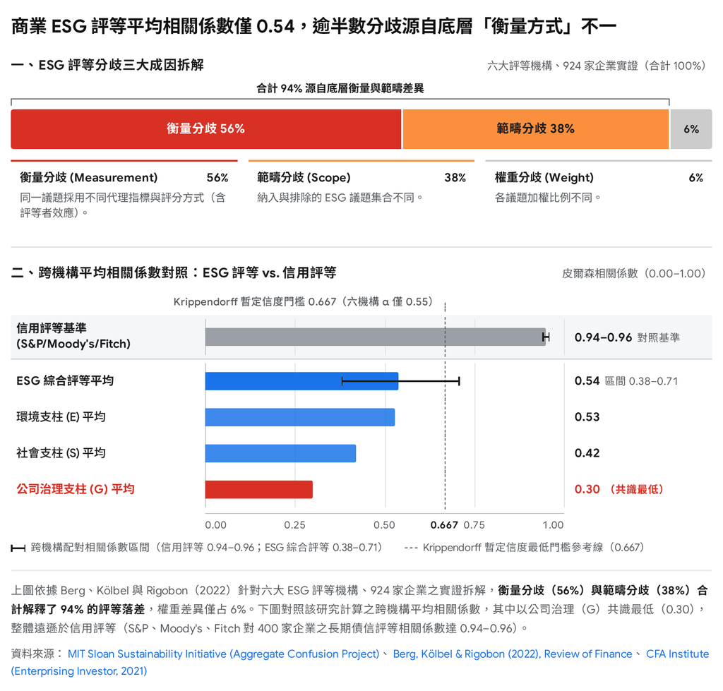

圖 3 ESG 評等分歧成因與跨機構相關係數（Gemini Deep Research 生成圖）

## 四、全球、台灣與學術 ESG 評估體系總表

下表依國際評等與基準、台灣評鑑與獎項、學術方法論三大類，彙整各機構與方法之起始年份、資料來源、核心指標與計分機制、是否逐題計分、是否對照 GRI、跨年資料能力及可查證網址。

| 類別 | 機構／方法名稱 | 起始年份 | 資料來源 | 指標設計與計分方式 | 是否逐題計分 | 是否對照 GRI | 跨年比較／歷年資料 | 可查證來源網址 |
| --- | --- | --- | --- | --- | --- | --- | --- | --- |
| **國際評等** | **MSCI ESG Ratings** | 1990 (指數) / 1999 (評等起源) / **2007** (時間序列) | 公開報告、政府／NGO 替代資料、每日媒體爭議（無問卷） [20] | 財務重大性；33 項關鍵議題依 GICS 選數項 E/S＋全面 G（≥33%）；曝險×管理扣爭議；同業相對 AAA–CCC [9] | 依產業挑選關鍵議題與指標計分（非全清單） [9] | 否（僅擷取公開報告為素材） [20] | 有（2007 年起時間序列） [18] | https://www.msci.com/data-and-analytics/sustainability-solutions/esg-ratings |
| **國際評等** | **Morningstar Sustainalytics** | 1992 (前身) / 2009 (合併) / **2018** (ESG Risk Ratings) | 公開揭露、公司專屬研究、媒體爭議＋企業回饋 [1] | 財務重大性；衡量「未管理 ESG 風險」開放式絕對分數（0 起跳，**越低越好**），五風險等級可跨產業比較 [1] | 有細項指標與 MEI 曝險／管理分解 [27] | 否（以企業價值風險為核心） [1] | 有（2018 起實測；2014–2017 模擬） [27] | https://www.sustainalytics.com/ |
| **國際評等** | **S&P Global CSA / DJSI (DJBIC)** | **1999** (2019 併自 RobecoSAM) | 企業主動填寫線上深度問卷＋公開佐證＋MSA 爭議監測 [35] | 同業最佳；61–62 產業各 80–100 題加權為 0–100 分；各產業前 10% 入選 DJSI World [32] | **是**（高度細緻逐題計分） [37] | 參考對齊，非逐條檢核 GRI 清單 [32] | 有（1999 年起每年辦理，題目逐年演進） [31] | https://www.marketplace.spglobal.com/en/solutions/corporate-sustainability-assessment-(68cedf2a-d83d-490d-93f8-134279282e29) |
| **國際評等** | **LSEG ESG Scores (原 Refinitiv / ASSET4)** | **2002** (歷史序列起點) | 純公開報告、申報文件＋全球媒體爭議（無問卷） [43] | 逾 630–870 資料點篩選 186 指標、10 類別；採產業／國家百分位排名（0–100、D- 至 A+），ESGC 納入爭議折減 [43] | 有細項布林／數值指標轉分，再行同業排名 [42] | 否（擷取公開揭露欄位） [43] | 有（2002 年起；學界曾揭露歷史重寫） [42] | https://www.lseg.com/en/data-analytics/sustainable-finance/sustainability-ratings-and-data |
| **國際評等** | **Bloomberg ESG Disclosure / ESG Scores** | **2009** (揭露分) / **2020** (績效分) | 純公開揭露資料、規則化自動模型（無問卷、無主觀意見） [10] | 揭露分（0–100）純測資訊完整度；ESG Scores（0–10、A–G）測財務重大性績效並乘以揭露因子 [2] | 有欄位級量化／二元計分（純二元議題權重折減 80%） [49] | 否（ESG Scores 主要參照 SASB） [50] | 有（逾 10 年歷史序列） [50] | https://professional.bloomberg.com/products/bloomberg-terminal/sustainable-finance/scores/ |
| **國際評等** | **ISS ESG (原 oekom)** | **1993** (oekom) / 2018 併入 ISS | 公開揭露、分析師研究、爭議監測＋發行人回饋 [55] | 約 100 產業指標（90% 產業專屬），4–5 關鍵議題占逾 50%；D- 至 A+，採產業絕對門檻判定 Prime [60] | **是**（指標與權重透明逐項計分） [60] | 參考 GRI、SASB、SDGs，非逐條檢核 [61] | 有年度更新（最早時間序列起始年未查證） [63] | https://www.iss-stoxx.com/research-advisory/sustainability-ratings/ |
| **國際評等** | **Moody's / Vigeo Eiris (V.E)** | 2002 (Vigeo) / 2015 (合併) / **2024 終止** | 過往以公開資訊為主；**2024/7 起關閉自有業務轉與 MSCI 合作** [12] | 過往採 E/S/G 平衡加權 0–100 分（Advanced ≥60） [66] | 歷史模型未再更新 | 否（歷史模型已退場） | **已停止新年度更新**，僅存歷史資料 [12] | https://ir.moodys.com/press-releases/news-details/2024/Moodys-and-MSCI-Announce-a-Strategic-Partnership-to-Enhance-Transparency-and-Deliver-Data-Driven-Risk-Solutions/default.aspx |
| **國際評等** | **FTSE Russell (FTSE4Good)** | **2001** | 嚴格純公開資料＋CDP 補充＋企業四週檢視（不發問卷） [72] | 3 支柱、14 主題、逾 300 指標（平均適用 125 項）；依曝險（1–3）加權主題分數（0–5），另設排除條款 [70] | **是**（規則導向指標級計分） [72] | 否（對應 17 項 SDGs，仰賴公開報告） [70] | 有（逾 20 年歷史） [70] | https://www.lseg.com/en/ftse-russell/indices/ftse4good |
| **專題／供應鏈** | **CDP** | 2000 (成立) / **2003** (首份問卷) | 企業主動填寫標準化線上環境問卷（2024 整合氣候／水／森林） [75] | 專注環境面（E）；揭露(D)→認知(C)→管理(B)→領導(A)四階梯＋必備條件（Essential Criteria），未答為 F [80] | **是**（公開數百頁逐題給分與比例計分規則） [81] | 否（主對齊 TCFD、IFRS S2、SBTi） [79] | 有（2003 年起，惟門檻逐年升級） [83] | https://www.cdp.net/en/disclosure-2026 |
| **專題／供應鏈** | **EcoVadis** | **2007** | 付費客製化問卷＋強制正式文件佐證＋360° 外部新聞監測 [85] | 供應鏈盡職調查；4 主題、21 準則、7 管理面向公式計分（0–100）；2024 起獎牌改採 12 個月動態百分位 [85] | **是**（21 準則×7 管理面向審核計分） [89] | **是**（明載建構於 GRI、ISO 26000、UNGC） [86] | 有企業續評與年度指數（獎牌門檻逐年墊高） [86] | https://support.ecovadis.com/hc/en-us/articles/115002531507-What-is-the-EcoVadis-methodology |
| **非營利基準** | **World Benchmarking Alliance (WBA)** | **2018** | 純公開資料（原則英文公開文件＋回饋補件），免費公開 [3] | 聚焦 **影響重大性** 與 SDG2000 企業；涵蓋人權、自然、金融、ITA 等系統轉型基準，採情境式計分 [3] | **是**（公開細項元素計分標準） [3] | 否（主對齊 UN SDGs 與人權指導原則） [3] | 有（定期輪動更新與 2026 統合記分板） [93] | https://www.worldbenchmarkingalliance.org/ |
| **媒體／研究排名** | **Corporate Knights (Global 100)** | **2005** | 純公開財報、永續報告與網站（年營收 >10 億美元，免報名） [98] | 2026 版聚焦核心永續營收比、永續投資比（第三 KPI 未查證）、CEO 薪酬連結加分，並扣罰款與職災死亡分 [99] | 否（屬精簡核心比率排名與加減分） [99] | 否（依自有開源永續經濟分類標準） [99] | 有（2005 年起完整百大資料集） [100] | https://corporateknights.com/rankings/global-100-rankings/ |
| **媒體／研究排名** | **Newsweek (AMRC / 原 Green Rankings)** | 2009 (Green) / **2020** (AMRC) | 公開永續報告書 KPI（逾 30 項）＋Statista 獨立公眾民調 [102] | 結合 E/S/G 公開比率與二元題及公眾聲譽評分，換算 0–100 分選出前 400–600 名 [101] | 部分（數十項公開 KPI 結合主觀民調） [102] | 否 [102] | 有歷年榜單（方法與名額曾調整） [105] | https://rankings.newsweek.com/americas-most-responsible-companies-2025 |
| **揭露追蹤** | **KPMG 全球永續報告大調查** | **1993** | 58 國／地區前百大（N100）與 G250 公開年報及永續報告 [108] | 不排企業名次，系統統計全球報告編製率、準則採用率、雙重重大性、淨零目標與確信比率 [108] | 否（屬宏觀趨勢調查） [108] | 追蹤 GRI 採用率，非企業打分 [110] | 有（1993 年起定期跨年追蹤） [108] | https://kpmg.com/xx/en/our-insights/sustainability/the-move-to-mandatory-reporting.html |
| **台灣監理** | **證交所公司治理評鑑 → ESG 評鑑** | **2014** (公司治理) / **2026** (轉型 ESG) | 公開資訊（觀測站、年報、永續報告、ESG 數位平台）＋裁罰紀錄；全體上市櫃受評 [4] | 2026 起重組為 E 21%、S 31%、G 48%；原則採是／否二元題＋進階加分＋重大違規減分，公布 7 級距 [4] | **是**（逐題二元計分與進階加分） [120] | 高度連動 GRI／IFRS，但不逐條照搬 GRI；另設 RBA 審閱查核 GRI 缺失 [111] | 有（2014 年起連續級距；2026 大轉型） [4] | https://cgc.twse.com.tw/esgEvaluation/listCh |
| **台灣資料庫** | **TEJ TESG 永續發展指標** | **2022** 發布（資料回溯 **2015**） | 公開永續報告、年報、財報、政府裁罰與事件雷達（無問卷）；2026 覆蓋 2,592 家 [125] | 獲 SASB 授權；E/S/G 三支柱、16 主題，結合量化變數與揭露度標準化為 0–100 分及 A+ 至 C- 七級（2026 新增 W 警告） [114] | 否（多變數標準化量化計分模型） [132] | **是**（以 GRI 檢視揭露，並採 SASB 權重） [132] | 有（2015 年起追蹤資料，每年更新兩次） [125] | https://www.tejwin.com/solution/esg-solution/ |
| **台灣指數／評鑑** | **臺灣指數公司：TIP 台灣永續評鑑 (SEED) 與臺灣永續指數** | **2016** (臺北大學) / **2017** (永續指數) / 2024 技轉 | 純公開資料（永續報告書、年報、官網、裁罰），無問卷 [142] | SEED 四構面（社會、經濟、環境、揭露）、22 次構面、325 類題項，分四大產業設正負向題計算得分率；永續指數則採 FTSE 模型 [136] | **是**（325 題項正負向逐題計分） [142] | **是**（緊密結合 GRI、CDP 與台灣法規，特設 D 構面） [142] | 有（2016 年起逐年擴增，2025 邁向全體上市櫃） [140] | https://irengage.taiwanindex.com.tw/news?id=14 |
| **台灣媒體獎** | **天下永續公民獎／評鑑** | **2007** | 企業主動付費報名（近 3 年 2 年獲利）＋線上問卷與專案＋公開爭議檢視 [147] | 公司治理、企業承諾、社會參與、環境永續四大構面；初選量化題採 Net Positive 1–3 分，決選專家分組評審 [147] | 初選量化問卷逐題計分；決選結合專家主觀評審 [147] | 參考 GRI／DJSI／SDGs，非逐條檢核 [150] | 有（2007 年起百強榜單，限報名企業） [145] | https://csr.cw.com.tw/esgaward/article/1002 |
| **台灣媒體獎** | **遠見 ESG 企業永續獎** | **2005** | 企業主動付費報名（綜合績效近 2 年無虧損）＋書面報告＋評審審查 [152] | 綜合績效（E/S/G 六組）與傑出方案（八組）雙軌並行；參考國際準則由評審團給分（內部細項配分未查證） [153] | 依構面評審給分（逐題細節未查證） [153] | 參考 GRI 等準則，非合規檢核 [154] | 有（2005 年起歷屆得獎名單，限報名企業） [153] | https://csr.gvm.com.tw/ |
| **台灣基金會獎** | **TCSA 台灣企業永續獎** | **2008**（官網另載 2007） | 企業主動付費報名＋永續報告書（綜合績效須第三方確信）＋5,000 字說明＋簡報 [158] | 綜合績效（8 構面 24 效標）、單項績效、永續報告獎（報告內容 60%＋多元媒體 40%，分白金至銅級） [158] | **是**（評審依構面與效標表逐項打分） [158] | **是**（報告獎與評審訓練高度對齊 GRI、IFRS） [158] | 有（逾 18 屆得獎紀錄，限報名參賽者） [156] | https://tcsaward.org.tw/tw/about/selection/TCSA |
| **台灣徵信** | **中華徵信所 CRIF Synesgy** | TOP5000 始於 1970；Synesgy 在台確切起始年未查證 | 企業線上自評問卷＋CRIF 徵信資料庫與 AI 分析 [165] | 依產業客製化問卷計分、產業基準比較與改善計畫，核發永續標章（細部等級劃分未查證）；另設 CRIF Synesgy Ratings [165] | **是**（結構化問卷逐題計分） [165] | **是**（2024 年獲 GRI 正式認證，亦符 ESRS） [170] | 具年度續評機制（在台公開長序列未查證） [165] | https://www.credit.com.tw/NEWcreditonline/Synesgy/ |
| **台灣專題／趨勢** | **商周×臺大風險中心「碳競爭力 100 強」** | **2022** | 連 3 年公開永續報告碳排數據＋問卷調查＋環境部裁罰排除 [173] | 專注碳排與財務效率（碳排減少率、碳生產力、承諾、決策層級、範疇三），2025 年涵蓋 582 家上市公司 [173] | 否（屬五大核心指標加權排名） [173] | 否（擷取報告書碳排欄位） [173] | 有（2022 年起連續年度追蹤） [173] | https://rsprc.ntu.edu.tw/web/news/video_in.jsp?lang=tw&np_id=NP1763710110460 |
| **台灣專題／趨勢** | **CSRone×政大信義書院 永續報告分析** | **2013**（政大 2016 加入） | 公開永續報告書（至 2025 年初累計蒐錄逾 7,100 本） [177] | 不排個別公司名次；大規模統計重大主題、治理、減碳、人權盡職調查與亞太 10 國揭露評分 [177] | 有結構化欄位盤點，輸出宏觀統計而非個股名次 [177] | **是**（完整盤點 GRI 重大主題與準則採用） [180] | 有（2013 年起連續 13 冊趨勢報告） [177] | https://csrone.com/reports/6813 |
| **學術方法** | **GRI 揭露指數 (Morhardt 2002 / Skouloudis 2009 / Michelon 2015)** | **2002** | 純公開永續報告書／年報 [182] | 逐條對照 GRI 項目以 0/1、0–3 或 0–4 分計分；Michelon (2015) 並檢驗象徵性揭露與資訊品質落差 [182] | **是**（逐條檢核） [182] | **是**（完全以 GRI 為藍本） [182] | 視研究設計（多為 1–5 年，樣本受人工限制） | https://ideas.repec.org/a/wly/corsem/v9y2002i4p215-233.html |
| **學術方法** | **Clarkson et al. (2008) 硬性／軟性評分法** | **2008** | 純公開永續報告書與企業網站 [190] | 依 GRI 設計 45 題、滿分 95 分：硬性可驗證指標（A1–A4，79 分）vs. 軟性一般宣稱（A5–A7，16 分） [192] | **是**（45 題分層逐題計分） [193] | **是**（以 GRI 環境指標為底本，後擴至三構面） [190] | 可跨年執行（原始論文為橫斷面，後續研究多用於跨年） [190] | https://www.researchgate.net/publication/4748813_Revisiting_the_Relation_Between_Environmental_Performance_and_Environmental_Disclosure_An_Empirical_Analysis |
| **學術方法** | **傳統內容分析與信度檢驗 (Milne & Adler 1999)** | 1990s（**1999** 信度標竿） | 公開年報與永續報告書 [198] | 以句子或頁數占比編碼主題、證據量化程度與正負面屬性，強調 Krippendorff's α 評分者間信度 [198] | 依編碼規則逐句歸類 [198] | 可搭配 GRI 主題表（原始法早於 GRI） [198] | 可跨年，但人工編碼成本極高 | https://ideas.repec.org/a/eme/aaajpp/09513579910270138.html |
| **學術方法** | **NLP／LLM 文本評分 (ClimateBERT / ChatReport / Sautner)** | **2021–2023** | 永續報告書、10-K 或法說會逐字稿 [204] | 領域語言模型分類、廉價談話指數（CTI）、RAG 自動化對照準則給 0–100 分（ChatReport）或法說會曝險 [203] | ChatReport 可自動逐項對照指引計分（須防幻覺） [210] | 目前主流以 TCFD／氣候為主，可遷移至 GRI [204] | **極強**（可低成本掃描數千家企業長跨年文本） [208] | https://arxiv.org/html/2307.15770v2 |
| **學術方法** | **評等分歧研究 (Berg et al. 2022 / Christensen et al. 2022)** | 2016 / **2022** | 跨國多機構商業 ESG 評等追蹤資料（如 6 大機構） [5] | 分解評等分歧為衡量 56%、範疇 38%、權重 6% 與評等者效應；驗證揭露越多反而擴大評等分歧 [5] | 不自建企業評等，專注評等信度解剖 [5] | 探討揭露標準缺乏共識對評等之影響 [221] | 多採多年度跨機構追蹤資料 [48] | https://academic.oup.com/rof/article/26/6/1315/6590670 |

## 五、深度比較：「以公開永續報告書逐題對照 GRI 計分並對上百家台灣上市公司做跨年比較」之定位、異同與方法論檢視

若一項研究採取「以公開永續報告書逐題對照 GRI 準則計分，對上百家台灣上市公司做跨年比較」**（下稱**「GRI 逐題跨年法」），放回全球與台灣評比光譜中審視，其血統最接近學術界的 **GRI 揭露指數（Morhardt 2002／Skouloudis 2009／Clarkson 2008）** 與台灣本土的 **TIP 台灣永續評鑑（SEED 模型）**，並在「純公開、不發問卷、規則透明可重現」原則上與 **FTSE Russell、WBA 及 Bloomberg ESG Disclosure Score** 高度呼應；相對地，它與 **MSCI、Sustainalytics、S&P CSA、EcoVadis 及台灣媒體獎項**在評估目標與資料機制上存在本質差異 [1]。以下從五個關鍵構面分析其異同與方法論風險。

### 1. 評估構念之根本差異：揭露深度 vs. 財務風險 vs. 實質績效

國際主流投資評等（如 MSCI、Sustainalytics、Bloomberg ESG Scores）核心在測量「外部永續因素回頭衝擊企業財務價值的風險韌性（財務重大性）」；Corporate Knights 與商周碳競爭力百強則直攻「永續營收比率或每噸碳排的營收產出（實質經濟績效）」；而 **GRI 逐題跨年法測量的核心構念是「企業依循影響重大性準則、向多方利害關係人交代環境與社會衝擊的揭露完整度與管理深度」** [1]。兩者不可混為一談。正如 Michelon et al.（2015）與 Bingler et al.（2022）所實證，報告書篇幅龐大、對照表條目勾選齊全，有時僅反映企業擅長合規書寫或「象徵性揭露」，未必代表較低排放強度或較佳財務抗震力 [188]。但換個角度看，也正因 GRI 逐題跨年法完全公開且逐條定義清晰，它得以避開 Berg et al.（2022）所指出的商業評等黑箱、56% 衡量分歧與評等者光環效應，使研究者能清楚交代「每一分究竟對應哪一條 GRI 揭露」 [5]。

### 2. 資料來源優勢與台灣母體的「法規擴編斷層」

相較於 S&P Global CSA、CDP、EcoVadis 及台灣的天下、遠見、TCSA 獎項皆須仰賴企業主動填卷或付費報名（無可避免存在「自選擇偏差」，往往只有大型、獲利穩健或重視公關形象的企業參與），**GRI 逐題跨年法直接取材自公開資訊觀測站之永續報告書，具備零問卷回收偏差、無商業付費衝突、可完全公開覆核三大優勢** [39]。然而在台灣脈絡下，單靠永續報告書仍有兩項結構風險：第一，缺乏**外部負向事件校正**（MSCI、LSEG、EcoVadis、證交所 ESG 評鑑與 TEJ TESG 均納入媒體爭議、政府裁罰或 W 警告扣分，但企業自編報告書容易報喜不報憂，證交所審閱 2024 年度報告書便查出 93 次未依 GRI 2-27 完整統計違規裁罰的缺失） [43]；第二，金管會於 **2025 年**才將強制編製報告書範圍由資本額 20 億元以上擴大至全體上市櫃公司 [114]。因此若跨年研究橫跨 2020–2025 年，**母體結構會出現明顯斷層**（前期偏重大型與強制產業龍頭，後期大量首次申報之中小型企業湧入）。研究設計必須嚴格區隔「平衡追蹤樣本（Balanced Panel，同一批連續出書之上百家公司）」與「全體非平衡樣本」，否則跨年平均得分可能因新進首年公司拉低而失真（如同資誠與成大 2025 年報告發現，2024 年度非強制產業自願確信比例自 53% 降至 38%，主因即為首次申報小型公司拉低母體平均） [118]。

### 3. 逐題計分的深度陷阱：「二元打勾」與「硬性／軟性」落差

證交所 ESG 評鑑與早期揭露研究常採「有揭露給 1 分、無揭露給 0 分」的二元計分，執行簡潔卻極易喪失鑑別度 [120]。證交所 2024 年度永續報告書審閱結果即是最佳明證：多數台灣上市公司都能列出 GRI 3-2 重大主題清單（僅 7 次缺失），卻在 **GRI 3-3 重大主題管理方針**（衝擊範圍、管理機制與成效）被點名 32 次；同樣地，企業普遍會說明董事薪酬結構，卻在 **GRI 2-19** 因漏寫「薪酬與永續績效連結」而高居缺失榜首（137 次） [111]。若 GRI 逐題跨年法僅採 0/1 檢查「GRI 對照表有沒有出現該編號」，幾乎會讓大型上市公司集體逼近滿分（天花板效應），看不出實質揭露品質差異。這正是為何 **Clarkson et al.（2008）** 的硬性（79 分）／軟性（16 分）切分、**Yadava & Sinha（2016）** 的 0–3 分層給分（將跨年量化數據列為滿分條件），以及 **TIP SEED 模型**刪除純質化環境目標給分的設計十分重要 [142]。

### 4. 跨產業比較的「分母兩難」

MSCI、Sustainalytics、TEJ TESG 與 TIP SEED 模型均透過產業分類（GICS、SASB 或四大產業）預設各產業適用指標與權重，藉此處理半導體、金融與傳產的營運差異 [9]。然而 GRI 強調由企業透過重大性評估自行界定重大主題，這為跨產業上百家公司的計分帶來典型的「分母兩難」：若採**固定全清單當分母**（所有公司皆除以相同 GRI 條目總數），高環境衝擊製造業天然適用較多 GRI 300 系列條目，金融業與輕資產服務業反而因「不適用」而在總分上居於劣勢；但若改採**各公司自宣重大主題當分母**，卻會懲罰誠實辨識出較多重大風險的企業，變相獎勵刻意縮減重大主題清單以拉高得分率的投機做法。較穩健的處理方式是將 GRI 架構分層計分：**通用準則（GRI 2 與 GRI 3）採全樣本統一固定分母**（所有上市公司皆須一視同仁揭露），而**主題準則（200／300／400 系列）則應參照 GRI 行業準則或證交所產業分類建立同業基準分母，或於同業內進行標準化比較（如 z-score 或產業百分位）** [7]。

### 5. 跨年比較的「準則改版斷層」與執行規模取捨

對上百家台灣上市公司執行跨年逐題比較，最容易忽略的隱形陷阱是**準則版本漂移**：跨年區間極可能橫跨 **GRI Standards 2016 版 → GRI 2021 通用準則改版（2023 年 1 月生效，原 102／103 重組為 GRI 2／GRI 3 並大幅強化人權盡職調查）**，乃至 2026 年起陸續接軌的 **GRI 101 生物多樣性**與 **GRI 102 氣候變遷** [111]。若未作版本校準而直接比較各年度原始條目得分，分數起伏可能僅源自準則重編而非企業實質進步。相較於商業資料庫改版時外界無從控管，學術研究可主動透過「GRI 2016–2021–2025 條文橋接表（Concordance Table）」，將主軸跨年比較鎖定於語意連貫之核心共同條目，並將人權盡職調查、生物多樣性等新準則獨立為新世代追蹤副指標，同時確保時間序列一致性與研究前瞻性 [228]。

| 比較構面 | 國際商業評等（如 MSCI / Sustainalytics / LSEG） | 台灣監理與資料庫（證交所 ESG 評鑑 / TEJ / TIP SEED） | 台灣民間獎項（天下 / 遠見 / TCSA） | 目標研究方法：「公開報告逐題對照 GRI 跨年法」 |
| --- | --- | --- | --- | --- |
| **核心衡量構念** | 財務重大性風險韌性或未管理風險 [1] | 政策合規引導＋本土化 ESG 綜合表現 [4] | 標竿實踐、專案創新與企業社會聲譽 [147] | **影響重大性下之資訊揭露完整度與深度** [7] |
| **樣本母體與偏差** | 全球大中型企業為主，台灣中小型覆蓋不足 | 覆蓋全體上市櫃／公發公司，無報名偏差 [121] | 僅涵蓋主動付費報名者，自選擇偏差顯著 [147] | 依研究選樣（上百家上市櫃）；須控管 2025 年強制擴編斷層 [114] |
| **透明度與可重現性** | 中至低（多為專利權重或黑箱，歷史偶有重寫） [5] | 證交所指標公開但個股原分不公開；TEJ 為商業模型；TIP SEED 題項架構較公開 [121] | 評審團主觀配分權重高，外部無法重現分數 [153] | **極高**（條文、評分規則與原文頁碼可完全公開重現） |
| **對負向爭議之敏感度** | 高（每日媒體監測與爭議扣分） [21] | 高（納入主管機關裁罰、環保罰款扣分或 W 警告） [121] | 中（獲獎前後重大違規可取消資格） [153] | **偏低**（純看報告書易受報喜不報憂影響，須外掛外部裁罰對照） |
| **跨年比較穩定度** | 具長序列，但商業機構改版或回溯重寫難控管 [18] | 具中長序列（2014–2016 起），但受政策改版影響 [4] | 僅見歷屆上榜名單，缺乏跨年連續分數 | **可控性高**（可透過 GRI 版本橋接表維持固定尺規），惟人工成本高 |

### 6. 對「GRI 逐題跨年法」之方法論強化建議

綜合國際評等分歧的實證教訓與台灣企業揭露問題，若希望「上百家台灣上市公司公開永續報告書逐題對照 GRI 跨年研究」同時具備嚴謹的學術效度與實務鑑別力，建議在研究設計納入四項強化步驟：

1. **導入「0–3 分層給分＋Clarkson 硬性／軟性雙構面分解」**：避免單純 0/1 勾選，依「0＝未揭露、1＝僅定性宣示或無佐證、2＝具體管理機制或單年量化數據、3＝具跨年趨勢比較、量化目標追蹤或第三方驗證」分層給分，並明確切分硬性可驗證指標與軟性宣稱指標，藉此檢驗台灣企業是否存在「高軟性、低硬性」的象徵性揭露現象 [182]。
2. **外掛「確信層級」與「外部負向裁罰／商業評等」進行效標驗證**：從報告書 GRI 2-5 與確信聲明區分「未確信」、「驗證機構 AA1000 查證」與「會計師 ISAE 3000 確信」，並與環境部／勞動部裁罰紀錄、TEJ TESG 或證交所 ESG 評鑑級距交叉比對，直接檢驗台灣市場中「GRI 揭露分數」與「實質合規／商業評等」究竟呈現收斂或背離（呼應 Christensen et al. 2022 的核心命題） [111]。
3. **建立嚴謹的「GRI 版本橋接表」與「同業分母控管」**：針對 2016 版、2021 版與後續新版 GRI 條文建立明確對照表，確保跨年尺規不漂移；通用準則（GRI 2／3）採全樣本固定分母，主題準則則按產業分組標準化，消除跨產業先天結構偏差 [112]。
4. **採「LLM＋RAG 輔助定位原文＋雙人盲審抽檢」混合工作流**：上百家公司乘以三至五年即達數百本、數萬頁的繁體中文報告書。純人工逐題編碼既耗時又易因疲勞降低一致性，全交給 LLM 打分又面臨幻覺與文字潤飾虛增分數的風險 [210]。較務實的架構是借鏡 ChatReport 的可追溯檢索設計，先由檢索系統將各 GRI 條文對應之原文段落與頁碼準確抽取出來，再由受過至少 20 份報告校準訓練的人工編碼員依明確決策規則判分，並計算與報告 **Krippendorff's α 評分者間信度** [199]。透過上述四項設計，此研究方法將能兼顧高度透明、跨年可比性與實質鑑別力，有效彌補商業 ESG 評等黑箱與分歧雜訊的結構盲點。

## 參考來源

1. Sustainalytics ESG Risk Ratings methodology, https://www.sustainalytics.com/docs/default-source/default-document-library/sustainalytics_esg-risk-ratings_methodology-abstract.pdf?sfvrsn=5b778b7f_8
2. Bloomberg ESG Disclosure Scores: A Data-Driven Approach, https://pomegra.io/learn/library/track-f-lifecycle/esg-investing/chapter-03-esg-ratings-disagreements/bloomberg-esg
3. Methodology for the 2026 Financial System Benchmark, https://www.worldbenchmarkingalliance.org/sites/default/files/2025-11/FinacialSystemBenchmark_Methodology2026-V2025_1_1.pdf
4. 公司治理評鑑轉型ESG評鑑 - 臺灣證券交易所, https://www.twse.com.tw/market_insights/zh/detail/8a8216d69bde495d019c0cf16bcb00e1
5. (PDF) Aggregate Confusion: The Divergence of ESG Ratings, https://www.researchgate.net/publication/360800553_Aggregate_Confusion_The_Divergence_of_ESG_Rating （驗證時網站阻擋自動存取，未能讀取內容）
6. GRI vs SASB vs ISSB: ESG Standards Compared for US Firms, https://www.oshaworkplacesafety.com/blog/gri-vs-sasb-vs-issb
7. SASB vs GRI: Key Differences Explained - Council Fire, https://www.councilfire.org/resources/compare/sasb-vs-gri
8. The GRI Standards, https://www.globalreporting.org/media/nmmnwfsm/gri-policymakers-guide.pdf
9. MSCI ESG Ratings Methodology | PDF | Governance - Scribd, https://www.scribd.com/document/1033787839/MSCI-ESG-Ratings-Methodology （驗證時網站阻擋自動存取，未能讀取內容）
10. Bloomberg ESG Scores Methodology: What the 2026 ERR Update, https://www.nossadata.com/blog/bloomberg-esg-scores-methodology-err-2026
11. ESG Ratings: Navigating Through the Haze, https://rpc.cfainstitute.org/blogs/enterprising-investor/2021/esg-ratings-navigating-through-the-haze
12. Shareholder notice-Fund changes, March 2025 - Invesco, https://www.invesco.com/content/dam/invesco/emea/en/product-documents/etf/other/shareholder-notice_en_esma-changes_040325.pdf （驗證時網站阻擋自動存取，未能讀取內容）
13. 公司治理評鑑自2026 年起轉型為ESG 評鑑 - 臺灣證券交易所, https://www.twse.com.tw/ESG/file/P29.pdf
14. Do commercial ties influence ESG ratings? Evidence from Moody's, https://ink.library.smu.edu.sg/cgi/viewcontent.cgi?article=3092&context=soa_research
15. ESG Rating Disagreement and ESG Disclosure: A Literature Review, https://www.worldscientific.com/doi/pdf/10.1142/S1094406026410027?download=true （驗證時網站阻擋自動存取，未能讀取內容）
16. ABCs of ESG Frameworks and Ratings, https://esgnavigator.com/knowledge-hub/esg-ratings-library/abcs-of-esg-ratings-reporting/
17. MSCI ESG Ratings - Reccessary, https://www.reccessary.com/en/reccpedia/msci-esg-ratings
18. ESG Ratings - MSCI, https://www.msci.com/data-and-analytics/sustainability-solutions/esg-ratings
19. Sustainability Indexes - MSCI, https://www.msci.com/indexes/category/esg-indexes （驗證時網站阻擋自動存取，未能讀取內容）
20. MSCI ESG Ratings, Methodology and Financial Performance, https://www.bursamalaysia.com/sites/5bb54be15f36ca0af339077a/content_entry6545042539fba2073dff6c40/6747c956cd34aacb6912d370/files/MSCI_Presentation_Nov_2024_FINAL.pdf?1732765729 （驗證時網站阻擋自動存取，未能讀取內容）
21. MSCI ESG Ratings Methodology | November 2020, https://fintech.mcu.edu.tw/wp-content/uploads/sites/42/2023/02/MSCI-ESG-Ratings-Methodology-Exec-Summary-Nov-2020.pdf
22. MSCI ESG Ratings Explained: How They Work, What Drives Your, https://www.nossadata.com/blog/msci-esg-rating-explained
23. MSCI ESG KLD STATS: 1991-2018 Data SetS, https://library.mcmaster.ca/sites/default/files/2024-11/MSCI_ESG_KLD_STATS_Data_Set_Methodology_Final.pdf （驗證時網站阻擋自動存取，未能讀取內容）
24. ESG Ratings Methodology, https://www.metzler.com/api/downloads/file/msci-esg-ratings-methodology.pdf
25. Sustainalytics - Wikipedia, https://en.wikipedia.org/wiki/Sustainalytics
26. Morningstar to Acquire Sustainalytics and Expand Access to ESG, https://newsroom.morningstar.com/news/news-details/2020/Morningstar-to-Acquire-Sustainalytics-and-Expand-Access-to-ESG-Research-Data-and-Analytics-for-Investors-Worldwide/default.aspx
27. ESG RISK RATINGS - Sustainalytics, https://www.sustainalytics.com/docs/default-source/default-document-library/client-portal/ds_standard_file_tearsheet-esg-risk-rating.pdf
28. ESG Risk Ratings: A 360° Review - Natixis Investment Managers, https://www.im.natixis.com/content/dam/natixis/website/insights/sustainable-investing/2023/esg-risk-ratings-a-360-review/sustainalytics-esg-2023-nim.pdf
29. Sustainalytics ESG Ratings Methodology Abstract | PDF | Risk - Scribd, https://www.scribd.com/document/552226139/Sustainalytics-ESG-Ratings-Methodology-Abstract （驗證時網站阻擋自動存取，未能讀取內容）
30. Sustainalytics: Home, https://www.sustainalytics.com/
31. Corporate Sustainability Assessment - S&P Global Marketplace, https://www.marketplace.spglobal.com/en/solutions/corporate-sustainability-assessment-(68cedf2a-d83d-490d-93f8-134279282e29)
32. Improve Your ESG Score: DJSI - EDGE Certification, https://www.edge-cert.org/wp-content/uploads/2023/02/edge-certfoundation-esgscoredjsi.pdf
33. Sustainable Finance: A Journey Toward ESG and Climate Risk, https://www.emerald.com/irere/article/18/1-2/1/1334041/Sustainable-Finance-A-Journey-Toward-ESG-and （驗證時網站阻擋自動存取，未能讀取內容）
34. Dow Jones Sustainability Indices Methodology - ISO 26000, https://iso26000.in/wp-content/uploads/downloads/documents/methodology-dj-sustainability-indices.pdf
35. Dow Jones Best-in-Class Indices Methodology - S&P Global, https://www.spglobal.com/spdji/en/documents/methodologies/methodology-dj-bic-indices.pdf （驗證時網站阻擋自動存取，未能讀取內容）
36. TS Holdings-Sustainability - 台新新光金控, https://www.tsholdings.com.tw/tsh/responsibility/blueprint/run/?__locale=en
37. S&P Global Corporate Sustainability Assessment | PDF - Scribd, https://www.scribd.com/document/710277222/DJSI-CSA-Measuring-Intangibles （驗證時網站阻擋自動存取，未能讀取內容）
38. Dow Jones Sustainability Index (DJSI) and ESG Reporting - Presgo, https://www.presgo.com/frameworks/djsi/
39. A Guide to the S&P Corporate Sustainability Assessment (CSA), https://www.adecesg.com/resources/blog/a-guide-to-the-sp-corporate-sustainability-assessment-csa/
40. （天下雜誌）COP30 系列報導DJSI企業全球第二多, https://tcan2050.org.tw/%EF%BC%88%E5%A4%A9%E4%B8%8B%E9%9B%9C%E8%AA%8C%EF%BC%89cop30-%E7%B3%BB%E5%88%97%E5%A0%B1%E5%B0%8E-djsi%E4%BC%81%E6%A5%AD%E5%85%A8%E7%90%83%E7%AC%AC%E4%BA%8C%E5%A4%9A%EF%BC%8C-%E5%8F%B0%E7%81%A3/
41. ESG Disclosure vs. ESG Ratings: Consistent Information Value?, https://www.efmaefm.org/0EFMAMEETINGS/EFMA%20ANNUAL%20MEETINGS/2024-Lisbon/papers/CompletePaper281.pdf
42. Environmental, social and governance scores from LSEG, https://www.lseg.com/content/dam/data-analytics/en_us/documents/methodology/lseg-esg-scores-methodology.pdf
43. LSEG D&A ESG Scores Methodology, https://www.lseg.com/content/dam/data-analytics/en_us/documents/methodology/lseg-da-esg-scores-methodology.pdf
44. ESG Scores and Data | Data Analytics - LSEG, https://www.lseg.com/en/data-analytics/sustainable-finance/sustainability-ratings-and-data
45. understanding esg scores based on companies with well, https://www.jananexusaves.com/uploads/2026/01/6a2b9c1eee608_JNAVES-015.pdf
46. Understanding ESG data and scores from Refinitiv - Issuer Services, https://lsegissuerservices.com/spark-insights/understanding-refinitiv-esg-data-scores/understanding-esg-data-and-scores-from-refinitiv
47. LSEG ESG scores composition: Out of more than 630 data points, https://www.researchgate.net/figure/LSEG-ESG-scores-composition-Out-of-more-than-630-data-points-186-are-selected-to_fig1_392496133 （驗證時網站阻擋自動存取，未能讀取內容）
48. The Aggregate Confusion Project | MIT Sloan Sustainability Initiative, https://mitsloan.mit.edu/sustainability-initiative/aggregate-confusion-project
49. Bloomberg ESG Scores Methodology, https://professional.bloomberg.com/globalassets/professional/products/bloomberg-terminal/sustainable-finance/scores/bloomberg-esg-scores-methodology.pdf?v=639069475520000000
50. Sustainability Scores | Bloomberg Professional Services, https://professional.bloomberg.com/products/bloomberg-terminal/sustainable-finance/scores/
51. Bloomberg ESG | Apex Insurance Brokers Wiki, https://apexinsurancebrokers.co.uk/wiki/bloomberg-esg/
52. Can financial literacy enhance ESG disclosures? - InK@SMU.edu.sg, https://ink.library.smu.edu.sg/cgi/viewcontent.cgi?article=3142&context=soa_research
53. Annex III.1 Disclosure Table | Date: October 2026, https://sfs.bloomberg.com/api/document/esg_scores_reg/Bloomberg%20ESG%20Scores%20Regulation%20Mapping.pdf
54. Which ESG scores work best for portfolio construction? | Insights, https://www.bloomberg.com/professional/insights/sustainable-finance/which-esg-scores-work-best-for-portfolio-construction/ （驗證時網站阻擋自動存取，未能讀取內容）
55. MEASURING AND DISCLOSING ENVIRONMENTAL, SOCIAL AND, https://publications.jrc.ec.europa.eu/repository/bitstream/JRC131932/JRC131932_01.pdf
56. Second Party Opinion (SPO) - Sustainability Quality of the Issuer, https://www.covestro.com/-/media/covestro/corporate/investors/debt/green-financing-framework/second-party-opinion-iss-esg---covestro-green-financing-framework
57. ESG Benchmarking & Sustainability Performance Data, https://www.iss-corporate.com/solutions/corporate-sustainability/benchmarking-intelligence/
58. Sustainability | ISS STOXX, https://www.iss-stoxx.com/sustainability/
59. Sustainability | ISS STOXX, https://www.issgovernance.com/sustainability/
60. Corporate Rating - AWS, https://iss-stoxx.s3.amazonaws.com/prod/wp-content/uploads/corporate-ratings.pdf
61. Methodology: ISS-oekom Corporate Rating, https://www.deka-etf.de/documents/iss_oekom_47_latest_de.pdf
62. See Your Rating - ISS-Corporate, https://www.iss-corporate.com/solutions/see-your-rating/
63. Sustainability Ratings | ISS STOXX, https://www.iss-stoxx.com/research-advisory/sustainability-ratings/
64. Methodology Library | ISS STOXX, https://www.issgovernance.com/esg/methodology-information/
65. Handbook of Sustainable Finance - HAL, https://hal.science/hal-04370824v7/file/HSF.pdf
66. Environmental, Social, and Governance - Summary Report 2023, https://www.esm.europa.eu/system/files/document/2024-07/2024.02042%20ESG%20Summary%20Report%2023_V3.pdf
67. Shareholder Notice - London Stock Exchange, https://www.londonstockexchange.com/en/news/article/shareholder-notice/16925040
68. Climate Action at Desjardins – 2024 Annual Disclosure., https://www.desjardins.com/content/dam/pdf/en/about-us/community/sustainable-development/reports/2024-climate-action.pdf
69. Moody's and MSCI Announce a Strategic Partnership to Enhance, https://ir.moodys.com/press-releases/news-details/2024/Moodys-and-MSCI-Announce-a-Strategic-Partnership-to-Enhance-Transparency-and-Deliver-Data-Driven-Risk-Solutions/default.aspx
70. FTSE4Good Index Series - LSEG, https://www.lseg.com/en/ftse-russell/indices/ftse4good
71. FTSE Blossom Goes Global | 시킹알파, https://kr.seekingalpha.com/article/4755963-ftse-blossom-goes-global （驗證時網站阻擋自動存取，未能讀取內容）
72. FTSE Russell ESG Data Model Methodology - LSEG, https://www.lseg.com/content/dam/ftse-russell/en_us/documents/policy-documents/ftse-russell-esg-data-model-methodology.pdf
73. FTSE Russell | Corporate Engagement Within Sustainable Investment, https://www.lseg.com/content/dam/ftse-russell/en_us/documents/other/ftse-russell-sustainable-investment-corporate-engagement-2023.pdf
74. FTSE4Good 20-year anniversary report - LSEG, https://www.lseg.com/content/dam/ftse-russell/en_us/documents/research/ftse4good-20th-anniversary.pdf
75. Using CDP as a tool to report on ESG strategy | Nexio Projects, https://nexioprojects.com/using-cdp-as-a-tool-to-report-on-esg-strategy/
76. What Is the Carbon Disclosure Project (CDP)? - IBM, https://www.ibm.com/think/topics/carbon-disclosure-project
77. Carbon Disclosure Project Report 2008 Global 500 - PwC, https://www.pwc.co.uk/building-public-trust-awards/assets/pdf/cdp_global_500_report_2008.pdf
78. CDP Disclosure 2026, https://www.cdp.net/en/disclosure-2026
79. CDP: What is the role of the former Carbon Disclosure Project?, https://www.tennaxia.com/en/blog/cdp-tout-savoir-sur-le-carbon-disclosure-project
80. Understand your score as a disclosing company - CDP Help Center, https://help.cdp.net/en-us/knowledgebase/article/KA-01160
81. CDP Full Corporate Scoring Introduction 2024, https://cdn.cdp.net/cdp-production/comfy/cms/files/files/000/009/176/original/CDP_Full_Corporate_Scoring_Introduction_2024.pdf
82. CDP Climate Change 2023 Scoring Methodology, https://guidance.cdp.net/en/guidance?cid=46&ctype=theme&idtype=ThemeID&incchild=1&microsite=0&otype=ScoringMethodology&page=1&tags=TAG-605,TAG-13071 （原匯出網址中「&micro」被轉成「µ」，已還原為 &microsite=0，修正後 HTTP 200）
83. The Importance of Climate-Related Information Disclosure | Research, https://www.tokyofoundation.org/research/detail.php?id=738
84. CDP Climate Change 2018 Scoring Methodology, https://guidance.cdp.net/en/guidance?ctype=theme&idtype=ThemeID&cid=2&otype=Scoringmethodology
85. EcoVadis Rating: How It Works and What Changed in 2026 - Gravity, https://www.gravityplatform.com/blog/ecovadis-guide-how-the-rating-works-and-who-gets-assessed
86. EcoVadis Explained: Improve Your Sustainability Rating & Score, https://getgoodlab.com/resources/ecovadis-101
87. What Is EcoVadis? An Introduction to Sustainability Ratings - Semtrio, https://semtrio.com/insights/blogs/what-is-ecovadis-introduction-to-sustainability-ratings
88. EcoVadis Ratings Methodology Overview and Principles, https://resources.ecovadis.com/whitepapers/ecovadis-ratings-methodology-overview-and-principles-2022-neutral
89. EcoVadis Sustainability Rating - Methodology disclosure document, https://ecovadis.com/wp-content/uploads/2026/04/EcoVadis-Sustainability-Rating-Methodology-disclosure-document-for-the-public-rating-users-and-rated-items.pdf
90. What it is and what are the advantages of the EcoVadis assessment, https://lanzigroup.com/en/what-it-is-and-what-are-the-advantages-of-the-ecovadis-assessment/
91. What is the EcoVadis methodology?, https://support.ecovadis.com/hc/en-us/articles/115002531507-What-is-the-EcoVadis-methodology （驗證時網站阻擋自動存取，未能讀取內容）
92. Our mission - World Benchmarking Alliance, https://www.worldbenchmarkingalliance.org/about-us/our-mission
93. World Benchmarking Alliance: Home, https://www.worldbenchmarkingalliance.org/
94. Nature and Climate: why the world can't afford to keep them separate, https://www.worldbenchmarkingalliance.org/latest/nature-and-climate-why-world-cant-afford-keep-them-separate
95. Public policy | World Benchmarking Alliance, https://www.worldbenchmarkingalliance.org/who-we-work-with/public-policy
96. SDG2000 methodology - World Benchmarking Alliance, https://www.worldbenchmarkingalliance.org/latest/sdg2000-methodology
97. Global 100 resources | Corporate Knights, https://corporateknights.com/resources/global-100-resources/
98. Global 100 | Corporate Knights, https://corporateknights.com/rankings/global-100-rankings/
99. Overview of Corporate Knights Rating Methodology, https://corporateknights.com/wp-content/uploads/2026/01/2026-01-05-2026_CK_Ratings_methodology.pdf
100. Rankings | Page 42 of 42 | Corporate Knights, https://corporateknights.com/rankings/page/42/
101. America's Most Responsible Companies 2025 - Newsweek Rankings, https://rankings.newsweek.com/americas-most-responsible-companies-2025
102. America's Most Responsible Companies 2022 Methodology, https://d.newsweek.com/en/file/462268/americas-most-responsible-companies-2022-methodology.pdf
103. Corporate Responsibility - Newsweek Rankings, https://rankings.newsweek.com/category/corporate-responsibility
104. Consumer Perceptions of CSR Communication - CORE, https://core.ac.uk/download/527695175.pdf （驗證時網站阻擋自動存取，未能讀取內容）
105. America's Most Responsible Companies 2021 - Newsweek, https://d.newsweek.com/en/file/460986/americas-most-responsible-companies-2021-methodology-v3.pdf
106. AMRC 2024 – Retail - Newsweek Rankings, https://rankings.newsweek.com/americas-most-responsible-companies-2024/retail
107. Xerox History Timeline of Business Innovation and Design, https://www.xerox.com/en-us/about/history-timeline
108. The move to mandatory reporting: Survey of Sustainability Reporting, https://kpmg.com/xx/en/our-insights/sustainability/the-move-to-mandatory-reporting.html
109. The move to mandatory reporting - KPMG agentic corporate services, https://assets.kpmg.com/content/dam/kpmgsites/uk/pdf/2024/11/survey-of-sustainability-reporting-executive-summary.pdf
110. 'Business as usual' for world's top companies as they get ahead of, https://kpmg.com/xx/en/media/press-releases/2024/11/business-as-usual-for-worlds-top-companies-as-they-get-ahead-of-mandatory-sustainability-reporting-rules.html
111. 證交所2024年度永續報告書審閱結果全解析：9大GRI缺失與氣候揭露, https://www.sustaihub.com/blog/%E8%AD%89%E4%BA%A4%E6%89%802024%E5%B9%B4%E5%BA%A6%E6%B0%B8%E7%BA%8C%E5%A0%B1%E5%91%8A%E6%9B%B8%E5%AF%A9%E9%96%B1%E7%B5%90%E6%9E%9C%E5%85%A8%E8%A7%A3%E6%9E%909%E5%A4%A7gri%E7%BC%BA%E5%A4%B1%E8%88%87%E6%B0%A3%E5%80%99%E6%8F%AD%E9%9C%B2%E5%BB%BA%E8%AD%B0/
112. ESG永續報告書資訊揭露重點解析 - 兩岸經貿網, https://www.seftb.org/cp-4-1938-1a709-1.html
113. Who we are - GRI, https://www.globalreporting.org/about-gri/who-we-are/
114. 永續報告書為何？有何參考準則？永續報告書內容一覽, https://www.tejwin.com/insight/sustainability-report/
115. IFRS S1 S2是什麼？看懂SASB與永續報告書揭露重點, https://www.tejwin.com/insight/%E6%8E%A5%E8%BB%8Cifrs%E6%B0%B8%E7%BA%8C%E6%8F%AD%E9%9C%B2%E6%BA%96%E5%89%87/
116. GRI vs SASB vs TCFD vs ESRS: ESG Standards Compared (2026), https://www.fruggr.io/en/esg-reporting-standards-compared-gri-sasb-tcfd-esrs/
117. ISSB issues inaugural global sustainability disclosure standards, https://www.ifrs.org/news-and-events/news/2023/06/issb-issues-ifrs-s1-ifrs-s2/
118. 永續資訊確信市場觀察報告 - 資誠聯合會計師事務所PwC Taiwan, https://www.pwc.tw/zh/publications/topic-sustainability/assets/sustainability-related-assurance-market-observation-report.pdf
119. 【法規解碼室】AI開始閱讀企業永續報告：台灣ESG資訊正式 ... - 就享知, https://www.digiknow.com.tw/knowledge/eb341fe07e964
120. ESG評鑑簡介 - 公司治理中心- 臺灣證券交易所, https://cgc.twse.com.tw/front/evaluationOverview
121. 公司治理宣導 - 臺灣證券交易所, https://wwwc.twse.com.tw/staticFiles/news/event/8a8216d6a0bdcc0001a0d24426ff0060.pdf
122. 《櫃買市場》櫃買中心推ESG評鑑宣導協助上櫃公司備戰 - 工商時報, https://www.ctee.com.tw/news/20261123700595-430201
123. 115年度（第一屆） ESG評鑑介紹暨評分指南及參考範例說明, https://cgc.twse.com.tw/static/20251201/8a828e179a37cb91019ad78a4d6f0055_%E5%AE%A3%E5%B0%8E%E8%AA%B2%E7%A8%8B%E7%B0%A1%E5%A0%B11-ESG%E8%A9%95%E9%91%91%E4%BB%8B%E7%B4%B9%E6%9A%A8%E8%A9%95%E5%88%86%E6%8C%87%E5%8D%97%E8%88%87%E7%AF%84%E4%BE%8B%E8%AA%AA%E6%98%8E.pdf
124. 第1 屆（115年）ESG評鑑 - TWSE 公司治理中心, https://cgc.twse.com.tw/esgEvaluation/listCh
125. 誠信爭議即時示警、永續揭露品質牽動評等升降- TESG永續發展指標, https://www.tejwin.com/news/tesg%E6%B0%B8%E7%BA%8C%E7%99%BC%E5%B1%95%E6%8C%87%E6%A8%99-2026%E5%B9%B4%E6%9C%80%E6%96%B0%E7%AD%89%E7%B4%9A%E7%99%BC%E5%B8%83/
126. TESG 等級對公司財務績效之影響The Impact of TESG ... - 財務金融系, https://finance.cyut.edu.tw/var/file/25/1025/img/834/39-2.pdf
127. 台灣經濟新報文化事業股份有限公司資料庫中心TAIWAN ECONOMIC, https://home.lib.fju.edu.tw/TC/sites/default/files/Database_file/TEJ%E6%94%B6%E9%8C%84%E6%B8%85%E5%96%AE%282025%29.pdf
128. 【TEJ財金研究院】TESG 永續發展指標深入分析！與評價乘數有關聯？, https://medium.com/tej%E8%B2%A1%E9%87%91%E7%A0%94%E7%A9%B6%E9%99%A2/tej%E8%B2%A1%E9%87%91%E7%A0%94%E7%A9%B6%E9%99%A2-tesg-%E6%B0%B8%E7%BA%8C%E7%99%BC%E5%B1%95%E6%8C%87%E6%A8%99%E6%B7%B1%E5%85%A5%E5%88%86%E6%9E%90-%E8%88%87%E8%A9%95%E5%83%B9%E4%B9%98%E6%95%B8%E6%9C%89%E9%97%9C%E8%81%AF-5a0c587b15c9 （驗證時網站阻擋自動存取，未能讀取內容）
129. ESG 永續發展解決方案 - TEJ台灣經濟新報, https://www.tejwin.com/solution/esg-solution/
130. TESG永續發展指標2022年最新等級發布！ - TEJ台灣經濟新報, https://www.tejwin.com/news/%E3%80%90%E7%94%A2%E5%93%81%E5%BF%AB%E8%A8%8A%E3%80%91tesg%E6%B0%B8%E7%BA%8C%E7%99%BC%E5%B1%95%E6%8C%87%E6%A8%99-2022%E5%B9%B4%E6%9C%80%E6%96%B0%E7%AD%89%E7%B4%9A%E7%99%BC%E5%B8%83%EF%BC%81/
131. TESG永续发展指标2022年最新等级发布！ - TEJ台灣經濟新報, https://www.tejwin.biz/news/%E3%80%90%E7%94%A2%E5%93%81%E5%BF%AB%E8%A8%8A%E3%80%91tesg%E6%B0%B8%E7%BA%8C%E7%99%BC%E5%B1%95%E6%8C%87%E6%A8%99-2022%E5%B9%B4%E6%9C%80%E6%96%B0%E7%AD%89%E7%B4%9A%E7%99%BC%E5%B8%83%EF%BC%81/
132. TESG永續發展指標，台灣企業專屬的ESG指標！ - TEJ台灣經濟新報, https://www.tejwin.com/news/%E5%8F%B0%E7%81%A3%E7%9A%84esg%E6%8C%87%E6%A8%99-tesg/
133. 掌握ESG數據，聚焦ESG議合內容- 機構投資人如何打造有效議合, https://www.tejwin.com/insight/%E6%A9%9F%E6%A7%8B%E6%8A%95%E8%B3%87%E4%BA%BA%E5%A6%82%E4%BD%95%E6%89%93%E9%80%A0%E6%9C%89%E6%95%88%E8%AD%B0%E5%90%88/
134. ESG 各個構面與議題之分數高低對公司信用風險和財務績效的影響, https://dba.nkust.edu.tw/uploads/asset/data/685cbadc2e63560f8ceb8523/06-01-%E9%BB%83%E6%94%BF%E6%86%B2.pdf
135. 深度解析揭露品質- TESG永續發展指標2026年首次評等發布！ | TEJ, https://today.line.me/tw/v3/article/eLKE6Jg
136. 臺灣永續指數 - TIP 臺灣指數公司, https://taiwanindex.com.tw/indexes/f4gtte
137. 合編臺灣永續指數(FTSE4Good TIP Taiwan ESG Index)，推動社會, https://taiwanindex.com.tw/news/71
138. 國內首檔追蹤「臺灣永續指數」之ETF訂於8月23日掛牌上市。 2019, https://taiwanindex.com.tw/news/125
139. 「臺灣永續指數」期貨6月8日上市, https://taiwanindex.com.tw/news/146
140. 臺北大學攜手臺灣指數公司推廣「台灣永續評鑑」 - ESG TIMES, https://esgtimes.com.tw/6545-2/
141. 臺灣指數公司「臺灣永續評鑑」介紹2024/10/31 - IR議合服務平台, https://irengage.taiwanindex.com.tw/news?id=14
142. 提升企業ESG評分-以台灣永續評鑑為例, https://dsp.tpex.org.tw/storage/csr/%E5%BE%9E%E5%84%AA%E7%A7%80%E5%88%B0%E5%8D%93%E8%B6%8A%EF%BC%9A%E6%8F%90%E5%8D%87%E4%BC%81%E6%A5%ADESG%E8%A9%95%E5%88%86-%E4%BB%A5%E5%8F%B0%E7%81%A3%E6%B0%B8%E7%BA%8C%E8%A9%95%E9%91%91%E7%82%BA%E4%BE%8B.pdf
143. 臺灣指數公司最新TIP 台灣永續評鑑結果揭示協助公司實踐永續策略, https://tidatw.org/2025/08/26/%E8%87%BA%E7%81%A3%E6%8C%87%E6%95%B8%E5%85%AC%E5%8F%B8%E6%9C%80%E6%96%B0-tip-%E5%8F%B0%E7%81%A3%E6%B0%B8%E7%BA%8C%E8%A9%95%E9%91%91%E7%B5%90%E6%9E%9C%E6%8F%AD%E7%A4%BA-%E5%8D%94%E5%8A%A9%E5%85%AC/
144. The Virtue Matrix: Corporate Responsibility | PDF - Scribd, https://www.scribd.com/document/885753237/Financial-Ethics-and-Social-Responsibility-Ch-1-Virtue-Matrix-Part-2-20230923 （驗證時網站阻擋自動存取，未能讀取內容）
145. 天下永續公民獎優異成績, https://csr.sinyi.com.tw/sd/world10.php
146. 2026年天下集團永續獎項評選說明會, https://csr.cw.com.tw/survey/2026ESG/guidebook.pdf （驗證時網站阻擋自動存取，未能讀取內容）
147. 永續公民獎－ESG｜天下雜誌, https://csr.cw.com.tw/esgaward/article/1002 （驗證時網站阻擋自動存取，未能讀取內容）
148. 2026天下永續公民獎完整榜單揭曉| 天下雜誌 - LINE TODAY, https://today.line.me/tw/v3/article/3N1RqJZ
149. 反映Net Positive實踐程度！首屆「天下永續公民評鑑」評核成績大公開, https://csr.cw.com.tw/article/44034 （驗證時網站阻擋自動存取，未能讀取內容）
150. 達和環保再獲《天下永續公民獎》肯定, https://www.tahoho.com.tw/zuixinxunxi/dahehuanbaozaihuotianxiayongxugongminjiangkending
151. 2026年天下永續公民獎評審名單－ESG, https://csr.cw.com.tw/esgaward/article/1344 （驗證時網站阻擋自動存取，未能讀取內容）
152. PowerPoint 簡報 - 2025遠見ESG企業永續獎, https://csr.gvm.com.tw/2022/2022CSR_presentation.pdf
153. 2025遠見ESG企業永續獎｜遠見雜誌, https://csr.gvm.com.tw/
154. 影響力．跨越40年｜遠見雜誌, https://event.gvm.com.tw/anniversary/40/gvimpact.html
155. 2027遠見ESG企業永續獎, https://event.gvm.com.tw/esg/
156. 深入了解TCSA台灣企業永續獎：獎項、評分機制、時程全攻略, https://greenpulseconsulting.com/tcsa/
157. 企業永續菁英培訓班簡章, https://tcsaward.org.tw/uploads/files/2018/resgitre/2020-training-brochure.pdf
158. 2026 第十九屆TCSA台灣企業永續獎, https://tcsaward.org.tw/tw/about/selection/TCSA
159. 永續獎項- 台灣永續能源研究基金會TAISE, https://taise.org.tw/services/award/
160. 2025 第18屆 - TCSA台灣企業永續獎, https://tcsaward.org.tw/uploads/files/2025/2025_tcsa_guideline.pdf
161. 2026企業永續菁英培訓班初階班登場掌握永續報告書撰寫與TCSA, https://tcsaward.org.tw/tw/news/index/685
162. 【TCSA 參獎實戰指南】「三」參獎策略：精準展現亮點績效, https://isoleader.blogspot.com/2025/10/tcsa.html
163. TOP 5000企業排名 - 中華徵信- CRIF Asia, https://www.tw.crifasia.com/credit-risk-management/enterprise-ranking/top-5000/
164. TOP5000企業排名全新升級打造無國界的數位憑證 - CRIF中華徵信所, https://www.credit.com.tw/CreditEpaper/Epaper/Theme.aspx?unit=596
165. Synesgy –全球國際供應鏈ESG永續管理&發展平台, https://www.credit.com.tw/NEWcreditonline/Synesgy/
166. 新聞中心 - 中華徵信- CRIF Asia, https://www.tw.crifasia.com/newsroom/crif-news/
167. 台灣經貿網與CRIF中華徵信所合作ESG認證方案 - 活動匯, https://events.taiwantrade.com/CRIF113
168. Synesgy - CRIF.com, https://www.crif.com/business/services/platforms/synesgy/
169. 定義ESG評等全新標準CRIF Synesgy Ratings成立, https://www.tw.crifasia.com/newsroom/crif-news/synesgy-ratings/
170. Synesgy - 綠策院有限公司, https://everlab360.wordpress.com/synesgy/
171. 台灣經貿網與CRIF中華徵信所合作ESG認證方案 - 活動匯, https://events.taiwantrade.com/CRIF114
172. 歐盟ESG 評分新規7月2日適用，ESG資料可信度成為供應鏈與金融, https://www.tw.crifasia.com/newsroom/crif-news/2026-esg-eu/
173. 2025 商周碳競爭力100強調查 - 台大風險中心- 臺灣大學, https://rsprc.ntu.edu.tw/web/news/video_in.jsp?lang=tw&np_id=NP1763710110460
174. 元大金控入選商周碳競爭力100 強發揮金融影響力攜手利害關係人落實, https://www.yuanta.com/Files/5fd8f66f-ba1b-4fec-9626-0aedbaa49dab/%E3%80%90%E5%85%83%E5%A4%A7%E9%87%91%E6%8E%A7%E6%96%B0%E8%81%9E%E7%A8%BF%E3%80%91%E5%85%83%E5%A4%A7%E9%87%91%E6%8E%A7%E5%85%A5%E9%81%B8%E5%95%86%E5%91%A8%E7%A2%B3%E7%AB%B6%E7%88%AD%E5%8A%9B100%E5%BC%B7%20%E7%99%BC%E6%8F%AE%E9%87%91%E8%9E%8D%E5%BD%B1%E9%9F%BF%E5%8A%9B%20%E6%94%9C%E6%89%8B%E5%88%A9%E5%AE%B3%E9%97%9C%E4%BF%82%E4%BA%BA%E8%90%BD%E5%AF%A6%E6%B8%9B%E7%A2%B3.pdf
175. 中聯資源連續四年名列《商業週刊》「碳·競爭力100強」企業, https://www.chc.com.tw/ap/news_pop.aspx?NEWSID=361
176. 遠東新兩度入選《商業周刊碳競爭力百強》低碳創新為產業之冠, https://www.fenc.com/zh-TW/news/detail/92542
177. 2025 臺灣暨亞太永續報告現況與趨勢, https://csrone.com/reports/6813
178. 2024 臺灣暨亞太永續報告現況與趨勢, https://csrone.com/reports/6805
179. 永續報告分析結果出爐臺灣連3年穩坐冠軍寶座！, https://csrone.com/news/9198
180. 2025第十一屆台灣暨亞太永續現況與趨勢分析發表會 - 信義書院, https://syschool.nccu.edu.tw/zh_tw/news/2025%E7%AC%AC%E5%8D%81%E4%B8%80%E5%B1%86%E5%8F%B0%E7%81%A3%E6%B0%B8%E7%BA%8C%E7%8F%BE%E6%B3%81%E8%88%87%E8%B6%A8%E5%8B%A2%E5%88%86%E6%9E%90%E7%99%BC%E8%A1%A8%E6%9C%83-24909283
181. 永續報告分析結果出爐臺灣連3年穩坐冠軍寶座！ - 倡議家- 聯合新聞網, https://ubrand.udn.com/ubrand/story/123930/8633134
182. (PDF) Scoring Sustainability Reports Using GRI 2011 Guidelines for, https://www.researchgate.net/publication/276836423_Scoring_Sustainability_Reports_Using_GRI_2011_Guidelines_for_Assessing_Environmental_Economic_and_Social_Dimensions_of_Leading_Public_and_Private_Indian_Companies （驗證時網站阻擋自動存取，未能讀取內容）
183. JOURNAL OF GLOBAL BUSINESS VOLUME 12 ISSUE 1 ISSN, https://static1.squarespace.com/static/5b85162bcc8fedc767ff5676/t/64a78507d7ab6828d30b45c4/1688700171526/JGB+1724.edited.pdf
184. Scoring corporate environmental and sustainability reports using, https://ideas.repec.org/a/wly/corsem/v9y2002i4p215-233.html
185. Performance Indictors disclosure in Sustainability Reports, https://ir.ucc.edu.gh/server/api/core/bitstreams/ad1c1cb6-3d79-430c-80b5-6e282cd62027/content
186. Development of an Evaluation Methodology for Triple Bottom Line, http://www1.aegean.gr/environment/site/security/phd/Appendix%203.pdf
187. Analysis of Sustainability Disclosures Using a Gri Based Evaluation, https://www.ijceas.com/ijceas/article/download/591/382
188. CSR reporting practices and the quality of disclosure - IDEAS/RePEc, https://ideas.repec.org/a/eee/crpeac/v33y2015icp59-78.html
189. CSR Reports, CSR Disclosure Quality, and Corporate Reputations, https://www.researchgate.net/publication/350897924_CSR_Reports_CSR_Disclosure_Quality_and_Corporate_Reputations_A_Systematic_Literature_Review （驗證時網站阻擋自動存取，未能讀取內容）
190. Environmental Performance and Disclosure Analysis | PDF - Scribd, https://www.scribd.com/document/643003186/2008-PeterM-clarkson-Revisiting-the-Relation-Between-Environmental-Performance-and-Environmental-Disclosure-an-Empirical-Analysis （驗證時網站阻擋自動存取，未能讀取內容）
191. (PDF) The relationship between environmental performance and, https://www.researchgate.net/publication/340517867_The_relationship_between_environmental_performance_and_environmental_disclosure_A_meta-analysis （驗證時網站阻擋自動存取，未能讀取內容）
192. Environmental costs, environmental disclosure, and tax avoidance, https://www.emerald.com/ijoes/article/40/2/281/1237773/Environmental-costs-environmental-disclosure-and （驗證時網站阻擋自動存取，未能讀取內容）
193. Environmental Disclosures of Sri Lankan Property Development, https://arfjournals.com/image/95327_3_bhagya.pdf
194. Corporate governance and sustainability reporting in the Australian, https://ro.ecu.edu.au/cgi/viewcontent.cgi?article=9275&context=ecuworkspost2013 （驗證時網站阻擋自動存取，未能讀取內容）
195. sustainability reporting an unsung corporate governance notch: an, https://www.noveltyjournals.com/upload/paper/SUSTAINABILITY%20REPORTING%20AN%20UNSUNG%20CORPORATE-16102023-4.pdf
196. Corporate social responsibility disclosure, CEO ... - Accounting, https://www.growingscience.com/ac/Vol8/ac_2021_153.pdf
197. Revisiting the Relation Between Environmental Performance and, https://www.researchgate.net/publication/4748813_Revisiting_the_Relation_Between_Environmental_Performance_and_Environmental_Disclosure_An_Empirical_Analysis （驗證時網站阻擋自動存取，未能讀取內容）
198. Exploring the reliability of social and environmental disclosures, https://www.researchgate.net/publication/238775839_Exploring_the_reliability_of_social_and_environmental_disclosures_content_analysis （驗證時網站阻擋自動存取，未能讀取內容）
199. Exploring the reliability of social and environmental disclosures, https://www.emerald.com/aaaj/article/12/2/237/650/Exploring-the-reliability-of-social-and （驗證時網站阻擋自動存取，未能讀取內容）
200. Exploring the reliability of social and environmental disclosures, https://ideas.repec.org/a/eme/aaajpp/09513579910270138.html
201. Julia Bingler | alphaXiv, https://www.alphaxiv.org/@julia-bingler
202. What ClimateBert has to say on corporate climate risk disclosures, https://ideas.repec.org/a/eee/finlet/v47y2022ipbs1544612322000897.html
203. How Cheap Talk in Climate Disclosures Relates to Climate, https://www.bayes.citystgeorges.ac.uk/__data/assets/pdf_file/0006/727152/ClimateBERT_Presentation-1.pdf （驗證時網站阻擋自動存取，未能讀取內容）
204. Cheap Talk and ClimateBERT: Insights on Corporate Climate Risk, https://www.studocu.vn/vn/document/truong-dai-hoc-kinh-te-dai-hoc-quoc-gia-ha-noi/phuong-phap-nghien-cuu-kinh-te/cheap-talk-and-climatebert-insights-on-corporate-climate-risk-disclosures/174205928 （驗證時網站阻擋自動存取，未能讀取內容）
205. ESGBERT: Language Model to Help with Classification Tasks, https://www.researchgate.net/publication/359530003_ESGBERT_Language_Model_to_Help_with_Classification_Tasks_Related_to_Companies'_Environmental_Social_and_Governance_Practices （驗證時網站阻擋自動存取，未能讀取內容）
206. Knowledge informed sustainability detection from short financial texts, https://aclanthology.org/2022.finnlp-1.31.pdf
207. ESG news sentiment and stock price reactions - EconStor, https://www.econstor.eu/bitstream/10419/298798/1/1891479563.pdf
208. (PDF) Firm‐Level Climate Change Exposure - ResearchGate, https://www.researchgate.net/publication/368920111_Firm-Level_Climate_Change_Exposure （驗證時網站阻擋自動存取，未能讀取內容）
209. Mobilizing Text As Data: European Accounting Review, https://www.tandfonline.com/doi/abs/10.1080/09638180.2023.2218423 （驗證時網站阻擋自動存取，未能讀取內容）
210. chatReport: Democratizing Sustainability Disclosure Analysis ... - arXiv, https://arxiv.org/html/2307.15770v2
211. Democratizing Sustainability Disclosure Analysis through LLM, https://www.researchgate.net/publication/372784520_CHATREPORT_Democratizing_Sustainability_Disclosure_Analysis_through_LLM-based_Tools （驗證時網站阻擋自動存取，未能讀取內容）
212. CHATREPORT: Democratizing Sustainability Disclosure Analysis, https://www.semanticscholar.org/paper/CHATREPORT%3A-Democratizing-Sustainability-Disclosure-Ni-Bingler/56ad2c35353b57653b5f14c33afca72fe21d2d20 （驗證時網站回傳驗證頁，未能讀取內容）
213. Scoring and Greenwashing Corporate Climate Disclosures using, https://aclanthology.org/2025.climatenlp-1.2.pdf
214. 運用大型語言模型及增強式檢索技術分析臺灣永續報告書內容與預測, https://etheses.lib.ntust.edu.tw/detail/8f977df83ce0007578884ce792017268/ （驗證時網站阻擋自動存取，未能讀取內容）
215. 應用文字探勘與機器學習於企業永續之分析, https://thesis.lib.nccu.edu.tw/thesis/detail/73ec370db23fa27f18940fead65c880a/?seq=6&goto=1 （驗證時伺服器無回應／錯誤，連結存在性未能確認）
216. AI × ESG — 台灣上市櫃永續報告書智慧分析, https://paperlab.cooperation.tw/cases/esg/
217. what ClimateBert has to say on corporate climate risk disclosures, https://ora.ox.ac.uk/objects/uuid:b2d17f2f-7099-41e6-b7b3-91d37f313828
218. Do ratings of firms converge? Implications for managers, investors, https://ideas.repec.org/a/bla/stratm/v37y2016i8p1597-1614.html
219. Do ratings of firms converge? Implications for managers, investors, https://econpapers.repec.org/RePEc:bla:stratm:v:37:y:2016:i:8:p:1597-1614
220. Aggregate Confusion: The Divergence of ESG Ratings, https://academic.oup.com/rof/article/26/6/1315/6590670 （驗證時網站阻擋自動存取，未能讀取內容）
221. Why is Corporate Virtue in the Eye of The Beholder? The Case of, https://www.hbs.edu/ris/Publication%20Files/20-084_6c5b0248-d117-4049-baad-c0e1877eb537.pdf
222. George Serafeim - Google Scholar, https://scholar.google.com/citations?user=K6T_Pg4AAAAJ&hl=en
223. CDP Full Corporate Questionnaire, https://cdn.cdp.net/cdp-production/comfy/cms/files/files/000/009/102/original/CDP_2024_Corporate_Questionnaire_Guidance_Modules_8-13.pdf
224. EcoVadis Index: The Trends Behind the 2020-2024 Sustainability, https://ecovadis.com/blog/ecovadis-index-the-trends-behind-the-2020-2024-sustainability-ratings/
225. ESG生態系| 永續報告書 - 臺灣證券交易所, https://www.twse.com.tw/ESG/zh/ESGecology.html
226. 2023遠見ESG企業永續獎, https://event.gvm.com.tw/esg/2023/
227. Environmental Disclosure Determinants in Dutch Listed Companies, https://www.redalyc.org/pdf/2571/257130668006_2.pdf
228. Item 02 – Impact reporting in the Public Sector, state of play and, https://www.globalreporting.org/media/uwef1ja0/item-02-gri-project-for-public-sector-discussion-paper.pdf

## 附錄 引用網址驗證摘要

Works cited 共 228 筆，去重後 228 個不同網址（內文與總表中直接寫出的 59 個網址皆包含在其中）。驗證方式：以 curl 實際連線（跟隨轉址），box 連不上者改用 WebFetch 由另一網路重試；PDF 以 pdftotext 取文字，再以引用該來源的句子之數字、英文詞與中文詞比對頁面內容。比對結果屬自動判讀，「支持」代表關鍵詞與數字大致出現在來源頁面中，並非逐句人工核對。

| 驗證結果 | 筆數 |
| --- | --- |
| 支持 | 71 |
| 部分支持 | 23 |
| 未能確認（關鍵詞吻合低） | 3 |
| 受阻，未能判讀 | 23 |
| 頁面為動態載入，未能判讀 | 1 |
| 頁面為動態載入或無文字層，未能判讀 | 5 |
| 無法連線，未能判讀 | 1 |
| 內文未引用（僅列於 Works cited） | 101 |

未能確認的引用（來源頁面可開啟，但頁面內容找不到該句的關鍵數字或用語，請引用前人工核對）：

- [112] 通用準則（GRI 2／3）採全樣本固定分母，主題準則則按產業分組標準化，消除跨產業先天結構偏差。…；來源：https://www.seftb.org/cp-4-1938-1a709-1.html
- [150] 參考 GRI／DJSI／SDGs，非逐條檢核…；來源：https://www.tahoho.com.tw/zuixinxunxi/dahehuanbaozaihuotianxiayongxugongminjiangkending
- [165] 全球累計逾 1,500 家品牌買主使用、逾 58 萬家供應商註冊，在台並與台灣經貿網及台新銀行等合作供應鏈評估與綠色融資…；來源：https://www.credit.com.tw/NEWcreditonline/Synesgy/

本報告引用的參考文獻僅確認網址可連線與內容大致相符，期刊論文之作者、卷期、頁碼等欄位未依 Crossref 逐欄核對。